# Содержание

- 1-Обзор данных
- 2-Предобработка данных
  - 2.1-Переименование столбцов
  - 2.2-Удаление пропусков
  - 2.3-Изменение типов данных
  - 2.4-Обработка дубликатов
  - 2.5-Категоризация данных
- 3-Исследовательский анализ данных
  - 3.1-Изучение параметров объектов
    - 3.1.1-Изучение общей площади
    - 3.1.2-Изучение жилой площади
    - 3.1.3-Изучение площади кухни
    - 3.1.4-Изучение цены объекта
    - 3.1.5-Изучение количества комнат
    - 3.1.6-Изучение высоты потолков
    - 3.1.7-Изучение типа этажа квартиры
    - 3.1.8-Изучение общего количества этажей
    - 3.1.9-Изучение расстояния до центра города
    - 3.1.10-Изучение расстояния до ближайшего парка
  - 3.2-Анализ скорости продажи квартир
  - 3.3-Анализ факторов, влияющих на полную стоимость
  - 3.4-Анализ стоимости м² в населённых пунктах
  - 3.5-Анализ взаимосвязи между стоимостью и расстоянием до центра
- 4-Общий вывод

# Исследование объявлений о продаже квартир

**Цель исследования** — определить рыночную стоимость объектов недвижимости.

**Для этого**:

- Проведём исследовательский анализ данных;
- Установим параметры, влияющие на цену объектов.

**Описание данных**

В этом исследовании будут использованы данные сервиса "Яндекс Недвижимость" — архив объявлений о продаже квартир в Санкт-Петербурге и соседних населённых пунктах за несколько лет. Мы получим их из файла `real_estate_data`.

По каждой квартире на продажу доступны два вида данных: внесённые пользователем и полученные автоматически из геосервисов на основе картографических данных (например, расстояние до центра, аэропорта и других объектов, количество парков и водоёмов). Объявления содержат следующую информацию:

- `airports_nearest` — расстояние до ближайшего аэропорта в метрах (м)
- `balcony` — число балконов
- `ceiling_height` — высота потолков (м)
- `cityCenters_nearest` — расстояние до центра города (м)
- `days_exposition` — сколько дней было размещено объявление (от публикации до снятия)
- `first_day_exposition` — дата публикации
- `floor` — этаж
- `floors_total` — всего этажей в доме
- `is_apartment` — апартаменты (булев тип)
- `kitchen_area` — площадь кухни в квадратных метрах (м²)
- `last_price` — цена на момент снятия с публикации
- `living_area` — жилая площадь в квадратных метрах (м²)
- `locality_name` — название населённого пункта
- `open_plan` — свободная планировка (булев тип)
- `parks_around3000` — число парков в радиусе 3 км
- `parks_nearest` — расстояние до ближайшего парка (м)
- `ponds_around3000` — число водоёмов в радиусе 3 км
- `ponds_nearest` — расстояние до ближайшего водоёма (м)
- `rooms` — число комнат
- `studio` — квартира-студия (булев тип)
- `total_area` — общая площадь квартиры в квадратных метрах (м²)
- `total_images` — число фотографий квартиры в объявлении

**Ход исследования**

Перед исследованием потребуется обзор данных, так как отсутствует информация об их качестве. Проверим данные на наличие ошибок и, по возможности, исправим их на этапе предобработки.

Таким образом, исследование пройдёт в 3 этапа:

1. Обзор данных.

Ознакомимся с содержанием, структурой и характеристиками данных. Посмотрим, какие потенциальные проблемы могут быть в данных, как распределены значения в столбцах с числами через гистограммы.

2. Предобработка данных.

Проведём более тщательную проверку на наличие ошибок и оценим их влияние. На этом этапе сосредоточимся на устранении наиболее критичных проблем, таких как пропуски, дубликаты, некорректный тип данных.

3. Исследовательский анализ данных.

Используя обработанные данные, проведём анализ и установим параметры, которые оказывают влияние на цену жилого объекта.

Результаты исследования позволят построить автоматизированную систему, которая отследит аномалии и мошенническую деятельность.

## Обзор данных

Откроем файл с данными и изучим общую информацию:

```python
# импортируем библиотеку pandas
import pandas as pd

# сохраним ссылку на файл в переменную
url = "https://code.s3.yandex.net/datasets/real_estate_data.csv"

# считаем данные из csv-файла в датафрейм и сохраним в переменную data
data = pd.read_csv(url, sep='\t')

# выведем первые 20 строчек датафрейма data на экран:
data.head(20)
```

|  | total_images | last_price | total_area | first_day_exposition | rooms | ceiling_height | floors_total | living_area | floor | is_apartment | ... | kitchen_area | balcony | locality_name | airports_nearest | cityCenters_nearest | parks_around3000 | parks_nearest | ponds_around3000 | ponds_nearest | days_exposition |
| --- | --- | --- | --- | --- | --- | --- | --- | --- | --- | --- | --- | --- | --- | --- | --- | --- | --- | --- | --- | --- | --- |
| 0 | 20 | 13000000.0 | 108.00 | 2019-03-07T00:00:00 | 3 | 2.70 | 16.0 | 51.00 | 8 | NaN | ... | 25.00 | NaN | Санкт-Петербург | 18863.0 | 16028.0 | 1.0 | 482.0 | 2.0 | 755.0 | NaN |
| 1 | 7 | 3350000.0 | 40.40 | 2018-12-04T00:00:00 | 1 | NaN | 11.0 | 18.60 | 1 | NaN | ... | 11.00 | 2.0 | посёлок Шушары | 12817.0 | 18603.0 | 0.0 | NaN | 0.0 | NaN | 81.0 |
| 2 | 10 | 5196000.0 | 56.00 | 2015-08-20T00:00:00 | 2 | NaN | 5.0 | 34.30 | 4 | NaN | ... | 8.30 | 0.0 | Санкт-Петербург | 21741.0 | 13933.0 | 1.0 | 90.0 | 2.0 | 574.0 | 558.0 |
| 3 | 0 | 64900000.0 | 159.00 | 2015-07-24T00:00:00 | 3 | NaN | 14.0 | NaN | 9 | NaN | ... | NaN | 0.0 | Санкт-Петербург | 28098.0 | 6800.0 | 2.0 | 84.0 | 3.0 | 234.0 | 424.0 |
| 4 | 2 | 10000000.0 | 100.00 | 2018-06-19T00:00:00 | 2 | 3.03 | 14.0 | 32.00 | 13 | NaN | ... | 41.00 | NaN | Санкт-Петербург | 31856.0 | 8098.0 | 2.0 | 112.0 | 1.0 | 48.0 | 121.0 |
| 5 | 10 | 2890000.0 | 30.40 | 2018-09-10T00:00:00 | 1 | NaN | 12.0 | 14.40 | 5 | NaN | ... | 9.10 | NaN | городской посёлок Янино-1 | NaN | NaN | NaN | NaN | NaN | NaN | 55.0 |
| 6 | 6 | 3700000.0 | 37.30 | 2017-11-02T00:00:00 | 1 | NaN | 26.0 | 10.60 | 6 | NaN | ... | 14.40 | 1.0 | посёлок Парголово | 52996.0 | 19143.0 | 0.0 | NaN | 0.0 | NaN | 155.0 |
| 7 | 5 | 7915000.0 | 71.60 | 2019-04-18T00:00:00 | 2 | NaN | 24.0 | NaN | 22 | NaN | ... | 18.90 | 2.0 | Санкт-Петербург | 23982.0 | 11634.0 | 0.0 | NaN | 0.0 | NaN | NaN |
| 8 | 20 | 2900000.0 | 33.16 | 2018-05-23T00:00:00 | 1 | NaN | 27.0 | 15.43 | 26 | NaN | ... | 8.81 | NaN | посёлок Мурино | NaN | NaN | NaN | NaN | NaN | NaN | 189.0 |
| 9 | 18 | 5400000.0 | 61.00 | 2017-02-26T00:00:00 | 3 | 2.50 | 9.0 | 43.60 | 7 | NaN | ... | 6.50 | 2.0 | Санкт-Петербург | 50898.0 | 15008.0 | 0.0 | NaN | 0.0 | NaN | 289.0 |
| 10 | 5 | 5050000.0 | 39.60 | 2017-11-16T00:00:00 | 1 | 2.67 | 12.0 | 20.30 | 3 | NaN | ... | 8.50 | NaN | Санкт-Петербург | 38357.0 | 13878.0 | 1.0 | 310.0 | 2.0 | 553.0 | 137.0 |
| 11 | 9 | 3300000.0 | 44.00 | 2018-08-27T00:00:00 | 2 | NaN | 5.0 | 31.00 | 4 | False | ... | 6.00 | 1.0 | Ломоносов | 48252.0 | 51677.0 | 0.0 | NaN | 0.0 | NaN | 7.0 |
| 12 | 10 | 3890000.0 | 54.00 | 2016-06-30T00:00:00 | 2 | NaN | 5.0 | 30.00 | 5 | NaN | ... | 9.00 | 0.0 | Сертолово | NaN | NaN | NaN | NaN | NaN | NaN | 90.0 |
| 13 | 20 | 3550000.0 | 42.80 | 2017-07-01T00:00:00 | 2 | 2.56 | 5.0 | 27.00 | 5 | NaN | ... | 5.20 | 1.0 | Петергоф | 37868.0 | 33058.0 | 1.0 | 294.0 | 3.0 | 298.0 | 366.0 |
| 14 | 1 | 4400000.0 | 36.00 | 2016-06-23T00:00:00 | 1 | NaN | 6.0 | 17.00 | 1 | NaN | ... | 8.00 | 0.0 | Пушкин | 20782.0 | 30759.0 | 0.0 | NaN | 1.0 | 96.0 | 203.0 |
| 15 | 16 | 4650000.0 | 39.00 | 2017-11-18T00:00:00 | 1 | NaN | 14.0 | 20.50 | 5 | NaN | ... | 7.60 | 1.0 | Санкт-Петербург | 12900.0 | 14259.0 | 1.0 | 590.0 | 1.0 | 296.0 | 19.0 |
| 16 | 11 | 6700000.0 | 82.00 | 2017-11-23T00:00:00 | 3 | 3.05 | 5.0 | 55.60 | 1 | NaN | ... | 9.00 | NaN | Санкт-Петербург | 22108.0 | 10698.0 | 3.0 | 420.0 | 0.0 | NaN | 397.0 |
| 17 | 6 | 4180000.0 | 36.00 | 2016-09-09T00:00:00 | 1 | NaN | 17.0 | 16.50 | 7 | NaN | ... | 11.00 | 1.0 | Санкт-Петербург | 33564.0 | 14616.0 | 0.0 | NaN | 1.0 | 859.0 | 571.0 |
| 18 | 8 | 3250000.0 | 31.00 | 2017-01-27T00:00:00 | 1 | 2.50 | 5.0 | 19.40 | 2 | NaN | ... | 5.60 | 1.0 | Санкт-Петербург | 44060.0 | 10842.0 | 1.0 | 759.0 | 0.0 | NaN | 168.0 |
| 19 | 16 | 14200000.0 | 121.00 | 2019-01-09T00:00:00 | 3 | 2.75 | 16.0 | 76.00 | 8 | NaN | ... | 12.00 | NaN | Санкт-Петербург | 38900.0 | 12843.0 | 0.0 | NaN | 0.0 | NaN | 97.0 |

20 rows × 22 columns

Предварительно в таблице с данными можно заметить следующие проблемы:

- Вещественные числа в столбце `last_price`. Для анализа нам понадобится цена квартиры, выраженная в рублях. К тому же, дробная часть, обозначающая копейки, равна нулю.
- Вещественный тип значений в столбцах: с количеством этажей в доме — `floors_total`, числом балконов — `balcony`, числом парков и водоёмов в радиусе 3 км. — `parks_around3000`, `ponds_around3000`, количеством дней, прошедших от публикации до снятия объявления — `days_exposition`.
- Пропущенные значения NaN в столбцах: `ceiling_height`, `living_area`, `is_apartment`, `kitchen_area`, `balcony`, `airports_nearest`, `cityCenters_nearest`, `parks_around3000`, `parks_nearest`, `ponds_around3000`, `ponds_nearest`, `days_exposition`.
- Название столбца `cityCenters_nearest` в сamel case вместо snake case. Недостаточно читаемые названия: `ponds_around3000` и `parks_around3000`.

```python
# выведем основную информацию о датафрейме с помощью метода info():
data.info()
```

```
<class 'pandas.core.frame.DataFrame'>
RangeIndex: 23699 entries, 0 to 23698
Data columns (total 22 columns):
 #   Column                Non-Null Count  Dtype
---  ------                --------------  -----
 0   total_images          23699 non-null  int64
 1   last_price            23699 non-null  float64
 2   total_area            23699 non-null  float64
 3   first_day_exposition  23699 non-null  object
 4   rooms                 23699 non-null  int64
 5   ceiling_height        14504 non-null  float64
 6   floors_total          23613 non-null  float64
 7   living_area           21796 non-null  float64
 8   floor                 23699 non-null  int64
 9   is_apartment          2775 non-null   object
 10  studio                23699 non-null  bool
 11  open_plan             23699 non-null  bool
 12  kitchen_area          21421 non-null  float64
 13  balcony               12180 non-null  float64
 14  locality_name         23650 non-null  object
 15  airports_nearest      18157 non-null  float64
 16  cityCenters_nearest   18180 non-null  float64
 17  parks_around3000      18181 non-null  float64
 18  parks_nearest         8079 non-null   float64
 19  ponds_around3000      18181 non-null  float64
 20  ponds_nearest         9110 non-null   float64
 21  days_exposition       20518 non-null  float64
dtypes: bool(2), float64(14), int64(3), object(3)
memory usage: 3.7+ MB
```

Почти половина столбцов датафрейма содержит пропуски. Больше всего пропущенных значений в столбце `is_apartment`. Согласно характеристикам датафрейма, тип данных столбца — `object`, хотя в описании данных указан тип `bool`.

Посмотрим на распределение значений в столбцах с числами:

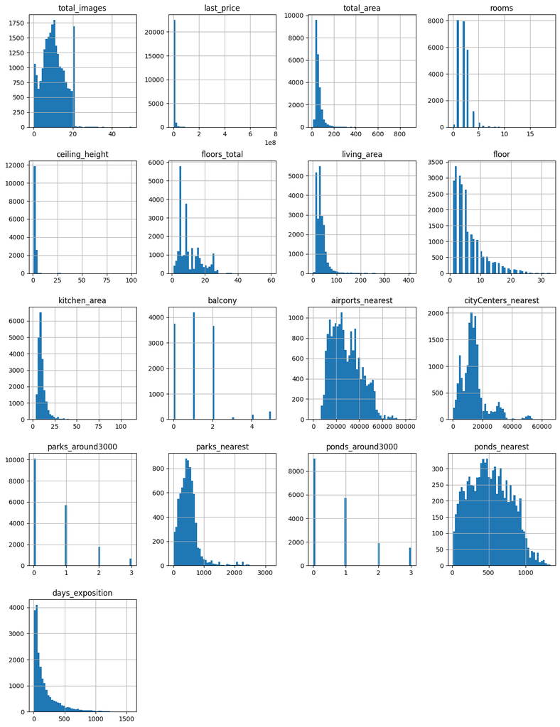

```python
# импортируем библиотеку matplotlib для работы с графиками
import matplotlib.pyplot as plt

# построим гистограмму, отображающую распределение значений в столбцах
# чтобы гистограмма стала более информативной, увеличим число корзин до 50
data.hist(figsize=(15,20), bins=50)

# выведем гистограмму
plt.show()
```

- На гистограмме по данным столбца `last_price` почти все значения собрались в одном столбце. На графике виден мощный узкий пик около значения **"0"**. Скорее всего, большинство значений в столбце близки к минимальному.
- Видны длинные хвосты в столбцах `total_area`, `living_area` и `kitchen_area`. Квартиры с общей площадью от **200**—**400 м²**, жилой площадью от **100—250 м²** и кухней более **40 м²** встречаются достаточно редко. Пока не ясно, можно ли отнести такие квартиры к элитному сегменту рынка или значения преимущественно завышены из-за проблем в данных. Требуется проанализировать цену и местоположение таких квартир.
- На гистограмме `ceiling_height` замечена отметка высоты потолка около **25 м**, что говорит об ошибке в данных.
- Вызывает сомнения длинный хвост в столбце `days_exposition` — более **1000 дней**. Можно предположить, что некоторые пользователи забыли снять объявления с публикации.

Предварительно можно утверждать, что остальные гистограммы выглядят правдоподобно. Однако каждый столбец требует более детального рассмотрения после этапа предобработки данных, выявления возможных аномалий, выбросов или ошибок.

**Выводы**

- Таблица состоит из **23699** строк и **22** столбцов. Каждая запись представляет собой объявление о продаже квартиры. Каждый столбец содержит информацию из объявления: например, цену на момент снятия с публикации, дату публикации, данные о местоположении квартиры и расстоянии до других объектов.
- В данных выявлены следующие проблемы: некорректный тип данных в некоторых столбцах и пропуски. Например, вещественные значения в столбцах с количеством этажей в доме и числом балконов должны быть целочисленными с логической точки зрения.
- Некорректное название столбца `cityCenters_nearest`. Недостаточно читаемые и информативные названия столбцов `ponds_around3000` и `parks_around3000`.
- Основная информация о таблице показывает, что **14** из **22** столбцов содержат пропущенные значения. Больше всего пропусков в столбцах `is_apartment`, `parks_nearest` и `ponds_nearest`. Пока сложно оценить, насколько это повлияет на результаты исследования.
- Высокие пики и длинные хвосты на гистограммах по столбцам `last_price`, `total_area`, `living_area`, `kitchen_area`, `ceiling_height` и `days_exposition` могут свидетельствовать об ошибках и аномалиях в данных. Каждая отдельная гистограмма требует более детального рассмотрения после предобработки данных.

## Предобработка данных

### Переименование столбцов

Проверим названия столбцов:

```python
# выведем перечень названий столбцов таблицы
data.columns
```

```
Index(['total_images', 'last_price', 'total_area', 'first_day_exposition',
       'rooms', 'ceiling_height', 'floors_total', 'living_area', 'floor',
       'is_apartment', 'studio', 'open_plan', 'kitchen_area', 'balcony',
       'locality_name', 'airports_nearest', 'cityCenters_nearest',
       'parks_around3000', 'parks_nearest', 'ponds_around3000',
       'ponds_nearest', 'days_exposition'],
      dtype='object')
```

Приведём название столбца `cityCenters_nearest` к змеиному регистру и заменим названия столбцов `ponds_around3000` и `parks_around3000` на более читаемые и информативные:

```python
# переименуем столбцы
data = data.rename(columns={'cityCenters_nearest':'city_centers_nearest', 'parks_around3000':'parks_around_3000m', 'ponds_around3000':'ponds_around_3000m'})

# проверим результат
data.columns
```

```
Index(['total_images', 'last_price', 'total_area', 'first_day_exposition',
       'rooms', 'ceiling_height', 'floors_total', 'living_area', 'floor',
       'is_apartment', 'studio', 'open_plan', 'kitchen_area', 'balcony',
       'locality_name', 'airports_nearest', 'city_centers_nearest',
       'parks_around_3000m', 'parks_nearest', 'ponds_around_3000m',
       'ponds_nearest', 'days_exposition'],
      dtype='object')
```

### Удаление пропусков

```python
# выведем на экран количество пропущенных значений для каждого столбца
# отсортируем результат по убыванию
data.isna().sum().sort_values(ascending=False)
```

```
is_apartment            20924
parks_nearest           15620
ponds_nearest           14589
balcony                 11519
ceiling_height           9195
airports_nearest         5542
city_centers_nearest     5519
ponds_around_3000m       5518
parks_around_3000m       5518
days_exposition          3181
kitchen_area             2278
living_area              1903
floors_total               86
locality_name              49
total_images                0
last_price                  0
studio                      0
floor                       0
rooms                       0
first_day_exposition        0
total_area                  0
open_plan                   0
dtype: int64
```

С одной стороны, пропуски присутствуют в столбцах с информацией, которую внёс пользователь: `is_apartment`, `balcony`, `ceiling_height`, `kitchen_area`, `living_area`, `floors_total`, `locality_name`. С другой стороны — в столбцах с данными о местоположении объекта, автоматически выгруженными из геосервисов: `parks_nearest`, `ponds_nearest`, `airports_nearest`, `city_centers_nearest`, `parks_around_3000m`, `ponds_around_3000m`, `days_exposition`.

Заполним пропущенные значения там, где это возможно.

Вероятно, пользователь оставил пропуски в столбце `is_apartment` если квартира не является апартаментами. Поэтому заменим пропуски на **False**:

```python
# заменим NaN в столбце 'is_apartment' на False с помощью метода fillna()
data['is_apartment'] = data['is_apartment'].fillna(value=False)

# проверим результат
data.isna().sum()
```

```
total_images                0
last_price                  0
total_area                  0
first_day_exposition        0
rooms                       0
ceiling_height           9195
floors_total               86
living_area              1903
floor                       0
is_apartment                0
studio                      0
open_plan                   0
kitchen_area             2278
balcony                 11519
locality_name              49
airports_nearest         5542
city_centers_nearest     5519
parks_around_3000m       5518
parks_nearest           15620
ponds_around_3000m       5518
ponds_nearest           14589
days_exposition          3181
dtype: int64
```

Также пользователь мог оставить пропуски в столбце с количеством балконов если их нет в квартире. Аналогично заменим такие пропуски на **0**:

```python
# заменим NaN в столбце 'balcony' на '0' c помощью метода fillna()
data['balcony'] = data['balcony'].fillna(value=0)

# проверим результат
data.isna().sum()
```

```
total_images                0
last_price                  0
total_area                  0
first_day_exposition        0
rooms                       0
ceiling_height           9195
floors_total               86
living_area              1903
floor                       0
is_apartment                0
studio                      0
open_plan                   0
kitchen_area             2278
balcony                     0
locality_name              49
airports_nearest         5542
city_centers_nearest     5519
parks_around_3000m       5518
parks_nearest           15620
ponds_around_3000m       5518
ponds_nearest           14589
days_exposition          3181
dtype: int64
```

Можно предположить, что пропуски в `days_exposition` возникли потому, что пользователь самостоятельно снял объявление с сайта. Этот столбец содержит количественные переменные, поэтому заполним пропуски медианным значением:

```python
# заполним пропуски медианой в столбце days_employed и сохраним результат
data['days_exposition'] = data['days_exposition'].fillna(data['days_exposition'].median())

# убедимся, что пропуски заполнены
data.isna().sum()
```

```
total_images                0
last_price                  0
total_area                  0
first_day_exposition        0
rooms                       0
ceiling_height           9195
floors_total               86
living_area              1903
floor                       0
is_apartment                0
studio                      0
open_plan                   0
kitchen_area             2278
balcony                     0
locality_name              49
airports_nearest         5542
city_centers_nearest     5519
parks_around_3000m       5518
parks_nearest           15620
ponds_around_3000m       5518
ponds_nearest           14589
days_exposition             0
dtype: int64
```

На количество этажей в доме сильнее всего влияет этаж квартиры. Поэтому заполним пропуски в этом столбце медианным значением по каждому этажу из столбца `floor`:

```python
# заполним пропуски медианой в столбце floors_total и сохраним результат
data['floors_total'] = data['floors_total'].fillna(data.groupby('floor')['floors_total'].transform('median'))

# убедимся, что пропуски заполнены
data.isna().sum()
```

```
total_images                0
last_price                  0
total_area                  0
first_day_exposition        0
rooms                       0
ceiling_height           9195
floors_total                0
living_area              1903
floor                       0
is_apartment                0
studio                      0
open_plan                   0
kitchen_area             2278
balcony                     0
locality_name              49
airports_nearest         5542
city_centers_nearest     5519
parks_around_3000m       5518
parks_nearest           15620
ponds_around_3000m       5518
ponds_nearest           14589
days_exposition             0
dtype: int64
```

Оставим пропуски в других столбцах без изменения, так как им невозможно предложить логичную замену.

В этом исследовании пропущенные значения являются сигналом, который важно учитывать. Например, пользователь мог намеренно не внести в объявление информацию о высоте потолков — `ceiling_height`, жилой площади — `living_area`, названии населённого пункта — `locality_name` и площади кухни — `kitchen_area`. Это может быть связано с попыткой скрыть недостатки объекта.

Пропуски в столбцах `parks_nearest` и `ponds_nearest` говорят о том, что рядом с объектом нет парков или водоёмов. Если мы заполним такие пропуски медианой, то исказим результаты исследования, создав видимость наличия парков и водоёмов. То же самое относится к пропущенным значениям в столбцах `airports_nearest` и `city_centers_nearest`.

Пропущенные значения в столбцах `parks_around_3000m` и `ponds_around_3000m`, вероятно, возникли из-за того, что геосервис не смог определить наличие парков и водоёмов в радиусе 3 км. Если сервис уверенно зафиксировал их отсутствие, он поставил **0**. Поэтому замена NaN на **0** может исказить данные, так как пропуски означают не отсутствие парков, а нехватку информации о них.

### Изменение типов данных

В некоторых столбцах нужно преобразовать значения в тип данных `int` с логической точки зрения. Таким обращом, заменим вещественный тип данных на целочисленный в столбцах: `last_price`, `floors_total`, `balcony`, `parks_around_3000m`, `ponds_around_3000m`, `days_exposition`:

```python
# сохраним список с названиями столбцов в переменной columns
# округлим значения с помощью метода round() и преобразуем тип данных в Int64, так как он может хранить NaN
columns = ['last_price', 'floors_total', 'balcony', 'parks_around_3000m', 'ponds_around_3000m', 'days_exposition']
data[columns] = data[columns].round().astype('Int64')

# проверим результат
print(data.info())
```

```
<class 'pandas.core.frame.DataFrame'>
RangeIndex: 23699 entries, 0 to 23698
Data columns (total 22 columns):
 #   Column                Non-Null Count  Dtype
---  ------                --------------  -----
 0   total_images          23699 non-null  int64
 1   last_price            23699 non-null  Int64
 2   total_area            23699 non-null  float64
 3   first_day_exposition  23699 non-null  object
 4   rooms                 23699 non-null  int64
 5   ceiling_height        14504 non-null  float64
 6   floors_total          23699 non-null  Int64
 7   living_area           21796 non-null  float64
 8   floor                 23699 non-null  int64
 9   is_apartment          23699 non-null  bool
 10  studio                23699 non-null  bool
 11  open_plan             23699 non-null  bool
 12  kitchen_area          21421 non-null  float64
 13  balcony               23699 non-null  Int64
 14  locality_name         23650 non-null  object
 15  airports_nearest      18157 non-null  float64
 16  city_centers_nearest  18180 non-null  float64
 17  parks_around_3000m    18181 non-null  Int64
 18  parks_nearest         8079 non-null   float64
 19  ponds_around_3000m    18181 non-null  Int64
 20  ponds_nearest         9110 non-null   float64
 21  days_exposition       23699 non-null  Int64
dtypes: Int64(6), bool(3), float64(8), int64(3), object(2)
memory usage: 3.6+ MB
None
```

В столбце с `датой публикации объявления` заменим тип данных с `object` на `datetime`. Это позволит использовать методы для работы с датами, осуществлять расчёты в ходе исследования и оптимизировать память, так как формат `datetime64` занимает меньше места, чем строковый формат:

```python
# преобразуем тип данных в datetime и сохраним результат в столбце
data['first_day_exposition'] = pd.to_datetime(
    data['first_day_exposition'], format='%Y-%m-%dT%H:%M:%S'
)

# проверим результат
data.info()
```

```
<class 'pandas.core.frame.DataFrame'>
RangeIndex: 23699 entries, 0 to 23698
Data columns (total 22 columns):
 #   Column                Non-Null Count  Dtype
---  ------                --------------  -----
 0   total_images          23699 non-null  int64
 1   last_price            23699 non-null  Int64
 2   total_area            23699 non-null  float64
 3   first_day_exposition  23699 non-null  datetime64[ns]
 4   rooms                 23699 non-null  int64
 5   ceiling_height        14504 non-null  float64
 6   floors_total          23699 non-null  Int64
 7   living_area           21796 non-null  float64
 8   floor                 23699 non-null  int64
 9   is_apartment          23699 non-null  bool
 10  studio                23699 non-null  bool
 11  open_plan             23699 non-null  bool
 12  kitchen_area          21421 non-null  float64
 13  balcony               23699 non-null  Int64
 14  locality_name         23650 non-null  object
 15  airports_nearest      18157 non-null  float64
 16  city_centers_nearest  18180 non-null  float64
 17  parks_around_3000m    18181 non-null  Int64
 18  parks_nearest         8079 non-null   float64
 19  ponds_around_3000m    18181 non-null  Int64
 20  ponds_nearest         9110 non-null   float64
 21  days_exposition       23699 non-null  Int64
dtypes: Int64(6), bool(3), datetime64[ns](1), float64(8), int64(3), object(1)
memory usage: 3.6+ MB
```

Чтобы использовать фильтрацию, делать срезы данных в ходе исследования и оптимизировать память, заменим тип данных в столбце `is_apartment` на `bool`, как указано в описании данных:

```python
# заменим тип данных на bool с помощью метода astype() и сохраним результат
data['is_apartment'] = data['is_apartment'].astype(bool)

# проверим результат
data.info()
```

```
<class 'pandas.core.frame.DataFrame'>
RangeIndex: 23699 entries, 0 to 23698
Data columns (total 22 columns):
 #   Column                Non-Null Count  Dtype
---  ------                --------------  -----
 0   total_images          23699 non-null  int64
 1   last_price            23699 non-null  Int64
 2   total_area            23699 non-null  float64
 3   first_day_exposition  23699 non-null  datetime64[ns]
 4   rooms                 23699 non-null  int64
 5   ceiling_height        14504 non-null  float64
 6   floors_total          23699 non-null  Int64
 7   living_area           21796 non-null  float64
 8   floor                 23699 non-null  int64
 9   is_apartment          23699 non-null  bool
 10  studio                23699 non-null  bool
 11  open_plan             23699 non-null  bool
 12  kitchen_area          21421 non-null  float64
 13  balcony               23699 non-null  Int64
 14  locality_name         23650 non-null  object
 15  airports_nearest      18157 non-null  float64
 16  city_centers_nearest  18180 non-null  float64
 17  parks_around_3000m    18181 non-null  Int64
 18  parks_nearest         8079 non-null   float64
 19  ponds_around_3000m    18181 non-null  Int64
 20  ponds_nearest         9110 non-null   float64
 21  days_exposition       23699 non-null  Int64
dtypes: Int64(6), bool(3), datetime64[ns](1), float64(8), int64(3), object(1)
memory usage: 3.6+ MB
```

Оставим тип данных `float` без изменений в столбцах: `total_area`, `living_area`, `kitchen_area` и `ceiling_height`. Площадь квартиры и высота потолков значительно влияют на цену объекта, поэтому округление значений приведёт к некорректным результатам анализа.

### Обработка дубликатов

Проверим данные на наличие явных дубликатов:

```python
# подсчитаем явные дубликаты
data.duplicated().sum()
```

```
0
```

Явные дубликаты отсутствуют в данных.

Cтолбец `locality_name` содержит категориальные переменные. Ознакомимся со списком уникальных значений столбца и проверим его на наличие неявных дубликатов:

```python
# ознакомимся с уникальными значениями с помощью метода unique()
data['locality_name'].unique()
```

```
array(['Санкт-Петербург', 'посёлок Шушары', 'городской посёлок Янино-1',
       'посёлок Парголово', 'посёлок Мурино', 'Ломоносов', 'Сертолово',
       'Петергоф', 'Пушкин', 'деревня Кудрово', 'Коммунар', 'Колпино',
       'поселок городского типа Красный Бор', 'Гатчина', 'поселок Мурино',
       'деревня Фёдоровское', 'Выборг', 'Кронштадт', 'Кировск',
       'деревня Новое Девяткино', 'посёлок Металлострой',
       'посёлок городского типа Лебяжье',
       'посёлок городского типа Сиверский', 'поселок Молодцово',
       'поселок городского типа Кузьмоловский',
       'садовое товарищество Новая Ропша', 'Павловск',
       'деревня Пикколово', 'Всеволожск', 'Волхов', 'Кингисепп',
       'Приозерск', 'Сестрорецк', 'деревня Куттузи', 'посёлок Аннино',
       'поселок городского типа Ефимовский', 'посёлок Плодовое',
       'деревня Заклинье', 'поселок Торковичи', 'поселок Первомайское',
       'Красное Село', 'посёлок Понтонный', 'Сясьстрой', 'деревня Старая',
       'деревня Лесколово', 'посёлок Новый Свет', 'Сланцы',
       'село Путилово', 'Ивангород', 'Мурино', 'Шлиссельбург',
       'Никольское', 'Зеленогорск', 'Сосновый Бор', 'поселок Новый Свет',
       'деревня Оржицы', 'деревня Кальтино', 'Кудрово',
       'поселок Романовка', 'посёлок Бугры', 'поселок Бугры',
       'поселок городского типа Рощино', 'Кириши', 'Луга', 'Волосово',
       'Отрадное', 'село Павлово', 'поселок Оредеж', 'село Копорье',
       'посёлок городского типа Красный Бор', 'посёлок Молодёжное',
       'Тихвин', 'посёлок Победа', 'деревня Нурма',
       'поселок городского типа Синявино', 'Тосно',
       'посёлок городского типа Кузьмоловский', 'посёлок Стрельна',
       'Бокситогорск', 'посёлок Александровская', 'деревня Лопухинка',
       'Пикалёво', 'поселок Терволово',
       'поселок городского типа Советский', 'Подпорожье',
       'посёлок Петровское', 'посёлок городского типа Токсово',
       'поселок Сельцо', 'посёлок городского типа Вырица',
       'деревня Кипень', 'деревня Келози', 'деревня Вартемяги',
       'посёлок Тельмана', 'поселок Севастьяново',
       'городской поселок Большая Ижора', nan,
       'городской посёлок Павлово', 'деревня Агалатово',
       'посёлок Новогорелово', 'городской посёлок Лесогорский',
       'деревня Лаголово', 'поселок Цвелодубово',
       'поселок городского типа Рахья', 'поселок городского типа Вырица',
       'деревня Белогорка', 'поселок Заводской',
       'городской посёлок Новоселье', 'деревня Большие Колпаны',
```

[output cut: 92 more lines]

```
       'деревня Ям-Тесово', 'деревня Раздолье', 'деревня Терпилицы',
       'посёлок Шугозеро', 'деревня Ваганово', 'поселок Пушное',
       'садовое товарищество Садко', 'посёлок Усть-Ижора',
       'деревня Выскатка', 'городской посёлок Свирьстрой',
       'поселок Громово', 'деревня Кисельня', 'посёлок Старая Малукса',
       'деревня Трубников Бор', 'поселок Калитино',
       'посёлок Высокоключевой', 'садовое товарищество Приладожский',
       'посёлок Пансионат Зелёный Бор', 'деревня Ненимяки',
       'поселок Пансионат Зелёный Бор', 'деревня Снегирёвка',
       'деревня Рапполово', 'деревня Пустынка', 'поселок Рабитицы',
       'деревня Большой Сабск', 'деревня Русско', 'деревня Лупполово',
       'деревня Большое Рейзино', 'деревня Малая Романовка',
       'поселок Дружноселье', 'поселок Пчевжа', 'поселок Володарское',
       'деревня Нижняя', 'коттеджный посёлок Лесное', 'деревня Тихковицы',
       'деревня Борисова Грива', 'посёлок Дзержинского'], dtype=object)
```

В списке большое количество неявных дубликатов, например: `'поселок городского типа Кузьмоловский'`/`'посёлок городского типа Кузьмоловский'`, `'поселок станции Вещево'`/`'посёлок при железнодорожной станции Вещево'`, `'посёлок Мурино'`/`'поселок Мурино'/'Мурино'`. По-разному дублируется именно обозначение типа населённого пункта, а не его название. В этом случае, удобно заменить не строки целиком, а их фрагменты - подстроки:

```python
# сохраняем список списков со старыми и новыми значениями
names_to_str_replace = [
    ['поселок','посёлок'],
    ['городской посёлок','посёлок'],
    ['посёлок городского типа','посёлок'],
    ['посёлок станции', 'посёлок'],
    ['посёлок при железнодорожной станции', 'посёлок'],
    ['садовое товарищество', 'посёлок'],
    ['коттеджный посёлок', 'посёлок'],
]

# производим замену для каждого значения столбца датафрейма, указанного в списке списков, с помощью метода str.replace()
for old_name, new_name in names_to_str_replace:
    data['locality_name'] = data['locality_name'].str.replace(old_name, new_name)

# проверяем результат
data['locality_name'].unique()
```

```
array(['Санкт-Петербург', 'посёлок Шушары', 'посёлок Янино-1',
       'посёлок Парголово', 'посёлок Мурино', 'Ломоносов', 'Сертолово',
       'Петергоф', 'Пушкин', 'деревня Кудрово', 'Коммунар', 'Колпино',
       'посёлок Красный Бор', 'Гатчина', 'деревня Фёдоровское', 'Выборг',
       'Кронштадт', 'Кировск', 'деревня Новое Девяткино',
       'посёлок Металлострой', 'посёлок Лебяжье', 'посёлок Сиверский',
       'посёлок Молодцово', 'посёлок Кузьмоловский',
       'посёлок Новая Ропша', 'Павловск', 'деревня Пикколово',
       'Всеволожск', 'Волхов', 'Кингисепп', 'Приозерск', 'Сестрорецк',
       'деревня Куттузи', 'посёлок Аннино', 'посёлок Ефимовский',
       'посёлок Плодовое', 'деревня Заклинье', 'посёлок Торковичи',
       'посёлок Первомайское', 'Красное Село', 'посёлок Понтонный',
       'Сясьстрой', 'деревня Старая', 'деревня Лесколово',
       'посёлок Новый Свет', 'Сланцы', 'село Путилово', 'Ивангород',
       'Мурино', 'Шлиссельбург', 'Никольское', 'Зеленогорск',
       'Сосновый Бор', 'деревня Оржицы', 'деревня Кальтино', 'Кудрово',
       'посёлок Романовка', 'посёлок Бугры', 'посёлок Рощино', 'Кириши',
       'Луга', 'Волосово', 'Отрадное', 'село Павлово', 'посёлок Оредеж',
       'село Копорье', 'посёлок Молодёжное', 'Тихвин', 'посёлок Победа',
       'деревня Нурма', 'посёлок Синявино', 'Тосно', 'посёлок Стрельна',
       'Бокситогорск', 'посёлок Александровская', 'деревня Лопухинка',
       'Пикалёво', 'посёлок Терволово', 'посёлок Советский', 'Подпорожье',
       'посёлок Петровское', 'посёлок Токсово', 'посёлок Сельцо',
       'посёлок Вырица', 'деревня Кипень', 'деревня Келози',
       'деревня Вартемяги', 'посёлок Тельмана', 'посёлок Севастьяново',
       'посёлок Большая Ижора', nan, 'посёлок Павлово',
       'деревня Агалатово', 'посёлок Новогорелово', 'посёлок Лесогорский',
       'деревня Лаголово', 'посёлок Цвелодубово', 'посёлок Рахья',
       'деревня Белогорка', 'посёлок Заводской', 'посёлок Новоселье',
       'деревня Большие Колпаны', 'деревня Горбунки', 'деревня Батово',
       'деревня Заневка', 'деревня Иссад', 'Приморск',
       'посёлок Фёдоровское', 'деревня Мистолово', 'Новая Ладога',
       'посёлок Зимитицы', 'посёлок Барышево', 'деревня Разметелево',
       'посёлок имени Свердлова', 'деревня Пеники', 'посёлок Рябово',
       'деревня Пудомяги', 'посёлок Корнево', 'деревня Низино',
       'деревня Бегуницы', 'посёлок Поляны', 'посёлок Мга',
       'посёлок Елизаветино', 'посёлок Кузнечное', 'деревня Колтуши',
       'посёлок Запорожское', 'деревня Гостилицы',
       'деревня Малое Карлино', 'посёлок Мичуринское',
       'посёлок имени Морозова', 'посёлок Песочный', 'посёлок Сосново',
```

[output cut: 50 more lines]

```
       'деревня Большая Пустомержа', 'посёлок Красносельское',
       'деревня Вахнова Кара', 'деревня Пижма', 'посёлок Кивеннапа Север',
       'посёлок Ромашки', 'деревня Каськово', 'деревня Куровицы',
       'посёлок Плоское', 'посёлок Кирпичное', 'деревня Ям-Тесово',
       'деревня Раздолье', 'деревня Терпилицы', 'посёлок Шугозеро',
       'деревня Ваганово', 'посёлок Пушное', 'посёлок Садко',
       'посёлок Усть-Ижора', 'деревня Выскатка', 'посёлок Свирьстрой',
       'деревня Кисельня', 'деревня Трубников Бор', 'посёлок Калитино',
       'посёлок Высокоключевой', 'посёлок Пансионат Зелёный Бор',
       'деревня Ненимяки', 'деревня Снегирёвка', 'деревня Рапполово',
       'деревня Пустынка', 'посёлок Рабитицы', 'деревня Большой Сабск',
       'деревня Русско', 'деревня Лупполово', 'деревня Большое Рейзино',
       'деревня Малая Романовка', 'посёлок Дружноселье', 'посёлок Пчевжа',
       'посёлок Володарское', 'деревня Нижняя', 'деревня Тихковицы',
       'деревня Борисова Грива', 'посёлок Дзержинского'], dtype=object)
```

Также заменим значения отдельных населённых пунктов, которые утратили статус `'посёлка'`/`'деревни'`. В этом случае, заменим не подстроки, а строки целиком:

```python
# создадим словарь со старыми и новыми значениями
names_to_replace = {
    'посёлок Мурино':'Мурино',
    'деревня Кудрово':'Кудрово'
}

# заменим значения в стобце датафрейма с помощью метода replace()
data['locality_name'] = data['locality_name'].replace(names_to_replace)

# проверим результат
data['locality_name'].unique()
```

```
array(['Санкт-Петербург', 'посёлок Шушары', 'посёлок Янино-1',
       'посёлок Парголово', 'Мурино', 'Ломоносов', 'Сертолово',
       'Петергоф', 'Пушкин', 'Кудрово', 'Коммунар', 'Колпино',
       'посёлок Красный Бор', 'Гатчина', 'деревня Фёдоровское', 'Выборг',
       'Кронштадт', 'Кировск', 'деревня Новое Девяткино',
       'посёлок Металлострой', 'посёлок Лебяжье', 'посёлок Сиверский',
       'посёлок Молодцово', 'посёлок Кузьмоловский',
       'посёлок Новая Ропша', 'Павловск', 'деревня Пикколово',
       'Всеволожск', 'Волхов', 'Кингисепп', 'Приозерск', 'Сестрорецк',
       'деревня Куттузи', 'посёлок Аннино', 'посёлок Ефимовский',
       'посёлок Плодовое', 'деревня Заклинье', 'посёлок Торковичи',
       'посёлок Первомайское', 'Красное Село', 'посёлок Понтонный',
       'Сясьстрой', 'деревня Старая', 'деревня Лесколово',
       'посёлок Новый Свет', 'Сланцы', 'село Путилово', 'Ивангород',
       'Шлиссельбург', 'Никольское', 'Зеленогорск', 'Сосновый Бор',
       'деревня Оржицы', 'деревня Кальтино', 'посёлок Романовка',
       'посёлок Бугры', 'посёлок Рощино', 'Кириши', 'Луга', 'Волосово',
       'Отрадное', 'село Павлово', 'посёлок Оредеж', 'село Копорье',
       'посёлок Молодёжное', 'Тихвин', 'посёлок Победа', 'деревня Нурма',
       'посёлок Синявино', 'Тосно', 'посёлок Стрельна', 'Бокситогорск',
       'посёлок Александровская', 'деревня Лопухинка', 'Пикалёво',
       'посёлок Терволово', 'посёлок Советский', 'Подпорожье',
       'посёлок Петровское', 'посёлок Токсово', 'посёлок Сельцо',
       'посёлок Вырица', 'деревня Кипень', 'деревня Келози',
       'деревня Вартемяги', 'посёлок Тельмана', 'посёлок Севастьяново',
       'посёлок Большая Ижора', nan, 'посёлок Павлово',
       'деревня Агалатово', 'посёлок Новогорелово', 'посёлок Лесогорский',
       'деревня Лаголово', 'посёлок Цвелодубово', 'посёлок Рахья',
       'деревня Белогорка', 'посёлок Заводской', 'посёлок Новоселье',
       'деревня Большие Колпаны', 'деревня Горбунки', 'деревня Батово',
       'деревня Заневка', 'деревня Иссад', 'Приморск',
       'посёлок Фёдоровское', 'деревня Мистолово', 'Новая Ладога',
       'посёлок Зимитицы', 'посёлок Барышево', 'деревня Разметелево',
       'посёлок имени Свердлова', 'деревня Пеники', 'посёлок Рябово',
       'деревня Пудомяги', 'посёлок Корнево', 'деревня Низино',
       'деревня Бегуницы', 'посёлок Поляны', 'посёлок Мга',
       'посёлок Елизаветино', 'посёлок Кузнечное', 'деревня Колтуши',
       'посёлок Запорожское', 'деревня Гостилицы',
       'деревня Малое Карлино', 'посёлок Мичуринское',
       'посёлок имени Морозова', 'посёлок Песочный', 'посёлок Сосново',
```

[output cut: 50 more lines]

```
       'деревня Большая Пустомержа', 'посёлок Красносельское',
       'деревня Вахнова Кара', 'деревня Пижма', 'посёлок Кивеннапа Север',
       'посёлок Ромашки', 'деревня Каськово', 'деревня Куровицы',
       'посёлок Плоское', 'посёлок Кирпичное', 'деревня Ям-Тесово',
       'деревня Раздолье', 'деревня Терпилицы', 'посёлок Шугозеро',
       'деревня Ваганово', 'посёлок Пушное', 'посёлок Садко',
       'посёлок Усть-Ижора', 'деревня Выскатка', 'посёлок Свирьстрой',
       'деревня Кисельня', 'деревня Трубников Бор', 'посёлок Калитино',
       'посёлок Высокоключевой', 'посёлок Пансионат Зелёный Бор',
       'деревня Ненимяки', 'деревня Снегирёвка', 'деревня Рапполово',
       'деревня Пустынка', 'посёлок Рабитицы', 'деревня Большой Сабск',
       'деревня Русско', 'деревня Лупполово', 'деревня Большое Рейзино',
       'деревня Малая Романовка', 'посёлок Дружноселье', 'посёлок Пчевжа',
       'посёлок Володарское', 'деревня Нижняя', 'деревня Тихковицы',
       'деревня Борисова Грива', 'посёлок Дзержинского'], dtype=object)
```

### Категоризация данных

Добавим в таблицу новый столбец `price_per_square_meter` с ценой одного квадратного метра:

```python
# напишем функцию с параметром - строка датафрейма
# проведём расчёты, округлим результат до 2 знаков после запятой
def square_meter_price(row):
    return round(row['last_price'] / row['total_area'], 2)

# вызовем функцию и сохраним результат в новый столбец
data['price_per_square_meter'] = data.apply(square_meter_price, axis=1)

data.head(20)
```

|  | total_images | last_price | total_area | first_day_exposition | rooms | ceiling_height | floors_total | living_area | floor | is_apartment | ... | balcony | locality_name | airports_nearest | city_centers_nearest | parks_around_3000m | parks_nearest | ponds_around_3000m | ponds_nearest | days_exposition | price_per_square_meter |
| --- | --- | --- | --- | --- | --- | --- | --- | --- | --- | --- | --- | --- | --- | --- | --- | --- | --- | --- | --- | --- | --- |
| 0 | 20 | 13000000 | 108.00 | 2019-03-07 | 3 | 2.70 | 16 | 51.00 | 8 | False | ... | 0 | Санкт-Петербург | 18863.0 | 16028.0 | 1 | 482.0 | 2 | 755.0 | 95 | 120370.37 |
| 1 | 7 | 3350000 | 40.40 | 2018-12-04 | 1 | NaN | 11 | 18.60 | 1 | False | ... | 2 | посёлок Шушары | 12817.0 | 18603.0 | 0 | NaN | 0 | NaN | 81 | 82920.79 |
| 2 | 10 | 5196000 | 56.00 | 2015-08-20 | 2 | NaN | 5 | 34.30 | 4 | False | ... | 0 | Санкт-Петербург | 21741.0 | 13933.0 | 1 | 90.0 | 2 | 574.0 | 558 | 92785.71 |
| 3 | 0 | 64900000 | 159.00 | 2015-07-24 | 3 | NaN | 14 | NaN | 9 | False | ... | 0 | Санкт-Петербург | 28098.0 | 6800.0 | 2 | 84.0 | 3 | 234.0 | 424 | 408176.10 |
| 4 | 2 | 10000000 | 100.00 | 2018-06-19 | 2 | 3.03 | 14 | 32.00 | 13 | False | ... | 0 | Санкт-Петербург | 31856.0 | 8098.0 | 2 | 112.0 | 1 | 48.0 | 121 | 100000.00 |
| 5 | 10 | 2890000 | 30.40 | 2018-09-10 | 1 | NaN | 12 | 14.40 | 5 | False | ... | 0 | посёлок Янино-1 | NaN | NaN | <NA> | NaN | <NA> | NaN | 55 | 95065.79 |
| 6 | 6 | 3700000 | 37.30 | 2017-11-02 | 1 | NaN | 26 | 10.60 | 6 | False | ... | 1 | посёлок Парголово | 52996.0 | 19143.0 | 0 | NaN | 0 | NaN | 155 | 99195.71 |
| 7 | 5 | 7915000 | 71.60 | 2019-04-18 | 2 | NaN | 24 | NaN | 22 | False | ... | 2 | Санкт-Петербург | 23982.0 | 11634.0 | 0 | NaN | 0 | NaN | 95 | 110544.69 |
| 8 | 20 | 2900000 | 33.16 | 2018-05-23 | 1 | NaN | 27 | 15.43 | 26 | False | ... | 0 | Мурино | NaN | NaN | <NA> | NaN | <NA> | NaN | 189 | 87454.76 |
| 9 | 18 | 5400000 | 61.00 | 2017-02-26 | 3 | 2.50 | 9 | 43.60 | 7 | False | ... | 2 | Санкт-Петербург | 50898.0 | 15008.0 | 0 | NaN | 0 | NaN | 289 | 88524.59 |
| 10 | 5 | 5050000 | 39.60 | 2017-11-16 | 1 | 2.67 | 12 | 20.30 | 3 | False | ... | 0 | Санкт-Петербург | 38357.0 | 13878.0 | 1 | 310.0 | 2 | 553.0 | 137 | 127525.25 |
| 11 | 9 | 3300000 | 44.00 | 2018-08-27 | 2 | NaN | 5 | 31.00 | 4 | False | ... | 1 | Ломоносов | 48252.0 | 51677.0 | 0 | NaN | 0 | NaN | 7 | 75000.00 |
| 12 | 10 | 3890000 | 54.00 | 2016-06-30 | 2 | NaN | 5 | 30.00 | 5 | False | ... | 0 | Сертолово | NaN | NaN | <NA> | NaN | <NA> | NaN | 90 | 72037.04 |
| 13 | 20 | 3550000 | 42.80 | 2017-07-01 | 2 | 2.56 | 5 | 27.00 | 5 | False | ... | 1 | Петергоф | 37868.0 | 33058.0 | 1 | 294.0 | 3 | 298.0 | 366 | 82943.93 |
| 14 | 1 | 4400000 | 36.00 | 2016-06-23 | 1 | NaN | 6 | 17.00 | 1 | False | ... | 0 | Пушкин | 20782.0 | 30759.0 | 0 | NaN | 1 | 96.0 | 203 | 122222.22 |
| 15 | 16 | 4650000 | 39.00 | 2017-11-18 | 1 | NaN | 14 | 20.50 | 5 | False | ... | 1 | Санкт-Петербург | 12900.0 | 14259.0 | 1 | 590.0 | 1 | 296.0 | 19 | 119230.77 |
| 16 | 11 | 6700000 | 82.00 | 2017-11-23 | 3 | 3.05 | 5 | 55.60 | 1 | False | ... | 0 | Санкт-Петербург | 22108.0 | 10698.0 | 3 | 420.0 | 0 | NaN | 397 | 81707.32 |
| 17 | 6 | 4180000 | 36.00 | 2016-09-09 | 1 | NaN | 17 | 16.50 | 7 | False | ... | 1 | Санкт-Петербург | 33564.0 | 14616.0 | 0 | NaN | 1 | 859.0 | 571 | 116111.11 |
| 18 | 8 | 3250000 | 31.00 | 2017-01-27 | 1 | 2.50 | 5 | 19.40 | 2 | False | ... | 1 | Санкт-Петербург | 44060.0 | 10842.0 | 1 | 759.0 | 0 | NaN | 168 | 104838.71 |
| 19 | 16 | 14200000 | 121.00 | 2019-01-09 | 3 | 2.75 | 16 | 76.00 | 8 | False | ... | 0 | Санкт-Петербург | 38900.0 | 12843.0 | 0 | NaN | 0 | NaN | 97 | 117355.37 |

20 rows × 23 columns

Создадим в датайрейме новый столбец `weekday_publication` с категориями дней недели публикации объявления:

- `'0'` — понедельник;
- `'1'` — вторник;
- `'2'` — среда;
- `'3'` — четверг;
- `'4'` — пятница;
- `'5'` — суббота;
- `'6'` — воскресенье.

```python
# используем метод dt.weekday, чтобы найти номер дня недели
# сохраним результат в новый столбец weekday_publication
data['weekday_publication'] = data['first_day_exposition'].dt.weekday

# выведем первые 20 строк датафрейма и проверим результат
data.head(20)
```

|  | total_images | last_price | total_area | first_day_exposition | rooms | ceiling_height | floors_total | living_area | floor | is_apartment | ... | locality_name | airports_nearest | city_centers_nearest | parks_around_3000m | parks_nearest | ponds_around_3000m | ponds_nearest | days_exposition | price_per_square_meter | weekday_publication |
| --- | --- | --- | --- | --- | --- | --- | --- | --- | --- | --- | --- | --- | --- | --- | --- | --- | --- | --- | --- | --- | --- |
| 0 | 20 | 13000000 | 108.00 | 2019-03-07 | 3 | 2.70 | 16 | 51.00 | 8 | False | ... | Санкт-Петербург | 18863.0 | 16028.0 | 1 | 482.0 | 2 | 755.0 | 95 | 120370.37 | 3 |
| 1 | 7 | 3350000 | 40.40 | 2018-12-04 | 1 | NaN | 11 | 18.60 | 1 | False | ... | посёлок Шушары | 12817.0 | 18603.0 | 0 | NaN | 0 | NaN | 81 | 82920.79 | 1 |
| 2 | 10 | 5196000 | 56.00 | 2015-08-20 | 2 | NaN | 5 | 34.30 | 4 | False | ... | Санкт-Петербург | 21741.0 | 13933.0 | 1 | 90.0 | 2 | 574.0 | 558 | 92785.71 | 3 |
| 3 | 0 | 64900000 | 159.00 | 2015-07-24 | 3 | NaN | 14 | NaN | 9 | False | ... | Санкт-Петербург | 28098.0 | 6800.0 | 2 | 84.0 | 3 | 234.0 | 424 | 408176.10 | 4 |
| 4 | 2 | 10000000 | 100.00 | 2018-06-19 | 2 | 3.03 | 14 | 32.00 | 13 | False | ... | Санкт-Петербург | 31856.0 | 8098.0 | 2 | 112.0 | 1 | 48.0 | 121 | 100000.00 | 1 |
| 5 | 10 | 2890000 | 30.40 | 2018-09-10 | 1 | NaN | 12 | 14.40 | 5 | False | ... | посёлок Янино-1 | NaN | NaN | <NA> | NaN | <NA> | NaN | 55 | 95065.79 | 0 |
| 6 | 6 | 3700000 | 37.30 | 2017-11-02 | 1 | NaN | 26 | 10.60 | 6 | False | ... | посёлок Парголово | 52996.0 | 19143.0 | 0 | NaN | 0 | NaN | 155 | 99195.71 | 3 |
| 7 | 5 | 7915000 | 71.60 | 2019-04-18 | 2 | NaN | 24 | NaN | 22 | False | ... | Санкт-Петербург | 23982.0 | 11634.0 | 0 | NaN | 0 | NaN | 95 | 110544.69 | 3 |
| 8 | 20 | 2900000 | 33.16 | 2018-05-23 | 1 | NaN | 27 | 15.43 | 26 | False | ... | Мурино | NaN | NaN | <NA> | NaN | <NA> | NaN | 189 | 87454.76 | 2 |
| 9 | 18 | 5400000 | 61.00 | 2017-02-26 | 3 | 2.50 | 9 | 43.60 | 7 | False | ... | Санкт-Петербург | 50898.0 | 15008.0 | 0 | NaN | 0 | NaN | 289 | 88524.59 | 6 |
| 10 | 5 | 5050000 | 39.60 | 2017-11-16 | 1 | 2.67 | 12 | 20.30 | 3 | False | ... | Санкт-Петербург | 38357.0 | 13878.0 | 1 | 310.0 | 2 | 553.0 | 137 | 127525.25 | 3 |
| 11 | 9 | 3300000 | 44.00 | 2018-08-27 | 2 | NaN | 5 | 31.00 | 4 | False | ... | Ломоносов | 48252.0 | 51677.0 | 0 | NaN | 0 | NaN | 7 | 75000.00 | 0 |
| 12 | 10 | 3890000 | 54.00 | 2016-06-30 | 2 | NaN | 5 | 30.00 | 5 | False | ... | Сертолово | NaN | NaN | <NA> | NaN | <NA> | NaN | 90 | 72037.04 | 3 |
| 13 | 20 | 3550000 | 42.80 | 2017-07-01 | 2 | 2.56 | 5 | 27.00 | 5 | False | ... | Петергоф | 37868.0 | 33058.0 | 1 | 294.0 | 3 | 298.0 | 366 | 82943.93 | 5 |
| 14 | 1 | 4400000 | 36.00 | 2016-06-23 | 1 | NaN | 6 | 17.00 | 1 | False | ... | Пушкин | 20782.0 | 30759.0 | 0 | NaN | 1 | 96.0 | 203 | 122222.22 | 3 |
| 15 | 16 | 4650000 | 39.00 | 2017-11-18 | 1 | NaN | 14 | 20.50 | 5 | False | ... | Санкт-Петербург | 12900.0 | 14259.0 | 1 | 590.0 | 1 | 296.0 | 19 | 119230.77 | 5 |
| 16 | 11 | 6700000 | 82.00 | 2017-11-23 | 3 | 3.05 | 5 | 55.60 | 1 | False | ... | Санкт-Петербург | 22108.0 | 10698.0 | 3 | 420.0 | 0 | NaN | 397 | 81707.32 | 3 |
| 17 | 6 | 4180000 | 36.00 | 2016-09-09 | 1 | NaN | 17 | 16.50 | 7 | False | ... | Санкт-Петербург | 33564.0 | 14616.0 | 0 | NaN | 1 | 859.0 | 571 | 116111.11 | 4 |
| 18 | 8 | 3250000 | 31.00 | 2017-01-27 | 1 | 2.50 | 5 | 19.40 | 2 | False | ... | Санкт-Петербург | 44060.0 | 10842.0 | 1 | 759.0 | 0 | NaN | 168 | 104838.71 | 4 |
| 19 | 16 | 14200000 | 121.00 | 2019-01-09 | 3 | 2.75 | 16 | 76.00 | 8 | False | ... | Санкт-Петербург | 38900.0 | 12843.0 | 0 | NaN | 0 | NaN | 97 | 117355.37 | 2 |

20 rows × 24 columns

Создадим в датайрейме новый столбец `month_publication` с месяцем публикации объявления:

```python
# используем метод dt.month, чтобы найти месяц
# сохраним результат в столбце month_publication
data['month_publication'] = data['first_day_exposition'].dt.month

# выведем первые 20 строк датафрейма и проверим результат
data.head(20)
```

|  | total_images | last_price | total_area | first_day_exposition | rooms | ceiling_height | floors_total | living_area | floor | is_apartment | ... | airports_nearest | city_centers_nearest | parks_around_3000m | parks_nearest | ponds_around_3000m | ponds_nearest | days_exposition | price_per_square_meter | weekday_publication | month_publication |
| --- | --- | --- | --- | --- | --- | --- | --- | --- | --- | --- | --- | --- | --- | --- | --- | --- | --- | --- | --- | --- | --- |
| 0 | 20 | 13000000 | 108.00 | 2019-03-07 | 3 | 2.70 | 16 | 51.00 | 8 | False | ... | 18863.0 | 16028.0 | 1 | 482.0 | 2 | 755.0 | 95 | 120370.37 | 3 | 3 |
| 1 | 7 | 3350000 | 40.40 | 2018-12-04 | 1 | NaN | 11 | 18.60 | 1 | False | ... | 12817.0 | 18603.0 | 0 | NaN | 0 | NaN | 81 | 82920.79 | 1 | 12 |
| 2 | 10 | 5196000 | 56.00 | 2015-08-20 | 2 | NaN | 5 | 34.30 | 4 | False | ... | 21741.0 | 13933.0 | 1 | 90.0 | 2 | 574.0 | 558 | 92785.71 | 3 | 8 |
| 3 | 0 | 64900000 | 159.00 | 2015-07-24 | 3 | NaN | 14 | NaN | 9 | False | ... | 28098.0 | 6800.0 | 2 | 84.0 | 3 | 234.0 | 424 | 408176.10 | 4 | 7 |
| 4 | 2 | 10000000 | 100.00 | 2018-06-19 | 2 | 3.03 | 14 | 32.00 | 13 | False | ... | 31856.0 | 8098.0 | 2 | 112.0 | 1 | 48.0 | 121 | 100000.00 | 1 | 6 |
| 5 | 10 | 2890000 | 30.40 | 2018-09-10 | 1 | NaN | 12 | 14.40 | 5 | False | ... | NaN | NaN | <NA> | NaN | <NA> | NaN | 55 | 95065.79 | 0 | 9 |
| 6 | 6 | 3700000 | 37.30 | 2017-11-02 | 1 | NaN | 26 | 10.60 | 6 | False | ... | 52996.0 | 19143.0 | 0 | NaN | 0 | NaN | 155 | 99195.71 | 3 | 11 |
| 7 | 5 | 7915000 | 71.60 | 2019-04-18 | 2 | NaN | 24 | NaN | 22 | False | ... | 23982.0 | 11634.0 | 0 | NaN | 0 | NaN | 95 | 110544.69 | 3 | 4 |
| 8 | 20 | 2900000 | 33.16 | 2018-05-23 | 1 | NaN | 27 | 15.43 | 26 | False | ... | NaN | NaN | <NA> | NaN | <NA> | NaN | 189 | 87454.76 | 2 | 5 |
| 9 | 18 | 5400000 | 61.00 | 2017-02-26 | 3 | 2.50 | 9 | 43.60 | 7 | False | ... | 50898.0 | 15008.0 | 0 | NaN | 0 | NaN | 289 | 88524.59 | 6 | 2 |
| 10 | 5 | 5050000 | 39.60 | 2017-11-16 | 1 | 2.67 | 12 | 20.30 | 3 | False | ... | 38357.0 | 13878.0 | 1 | 310.0 | 2 | 553.0 | 137 | 127525.25 | 3 | 11 |
| 11 | 9 | 3300000 | 44.00 | 2018-08-27 | 2 | NaN | 5 | 31.00 | 4 | False | ... | 48252.0 | 51677.0 | 0 | NaN | 0 | NaN | 7 | 75000.00 | 0 | 8 |
| 12 | 10 | 3890000 | 54.00 | 2016-06-30 | 2 | NaN | 5 | 30.00 | 5 | False | ... | NaN | NaN | <NA> | NaN | <NA> | NaN | 90 | 72037.04 | 3 | 6 |
| 13 | 20 | 3550000 | 42.80 | 2017-07-01 | 2 | 2.56 | 5 | 27.00 | 5 | False | ... | 37868.0 | 33058.0 | 1 | 294.0 | 3 | 298.0 | 366 | 82943.93 | 5 | 7 |
| 14 | 1 | 4400000 | 36.00 | 2016-06-23 | 1 | NaN | 6 | 17.00 | 1 | False | ... | 20782.0 | 30759.0 | 0 | NaN | 1 | 96.0 | 203 | 122222.22 | 3 | 6 |
| 15 | 16 | 4650000 | 39.00 | 2017-11-18 | 1 | NaN | 14 | 20.50 | 5 | False | ... | 12900.0 | 14259.0 | 1 | 590.0 | 1 | 296.0 | 19 | 119230.77 | 5 | 11 |
| 16 | 11 | 6700000 | 82.00 | 2017-11-23 | 3 | 3.05 | 5 | 55.60 | 1 | False | ... | 22108.0 | 10698.0 | 3 | 420.0 | 0 | NaN | 397 | 81707.32 | 3 | 11 |
| 17 | 6 | 4180000 | 36.00 | 2016-09-09 | 1 | NaN | 17 | 16.50 | 7 | False | ... | 33564.0 | 14616.0 | 0 | NaN | 1 | 859.0 | 571 | 116111.11 | 4 | 9 |
| 18 | 8 | 3250000 | 31.00 | 2017-01-27 | 1 | 2.50 | 5 | 19.40 | 2 | False | ... | 44060.0 | 10842.0 | 1 | 759.0 | 0 | NaN | 168 | 104838.71 | 4 | 1 |
| 19 | 16 | 14200000 | 121.00 | 2019-01-09 | 3 | 2.75 | 16 | 76.00 | 8 | False | ... | 38900.0 | 12843.0 | 0 | NaN | 0 | NaN | 97 | 117355.37 | 2 | 1 |

20 rows × 25 columns

Создадим в датайрейме новый столбец `year_publication` с годом публикации объявления:

```python
# используем метод dt.year, чтобы найти год публикации объявления
# сохраним результат в новом столбце year_publication
data['year_publication'] = data['first_day_exposition'].dt.year

# выведем первые 20 строк датафрейма и проверим результат
data.head(20)
```

|  | total_images | last_price | total_area | first_day_exposition | rooms | ceiling_height | floors_total | living_area | floor | is_apartment | ... | city_centers_nearest | parks_around_3000m | parks_nearest | ponds_around_3000m | ponds_nearest | days_exposition | price_per_square_meter | weekday_publication | month_publication | year_publication |
| --- | --- | --- | --- | --- | --- | --- | --- | --- | --- | --- | --- | --- | --- | --- | --- | --- | --- | --- | --- | --- | --- |
| 0 | 20 | 13000000 | 108.00 | 2019-03-07 | 3 | 2.70 | 16 | 51.00 | 8 | False | ... | 16028.0 | 1 | 482.0 | 2 | 755.0 | 95 | 120370.37 | 3 | 3 | 2019 |
| 1 | 7 | 3350000 | 40.40 | 2018-12-04 | 1 | NaN | 11 | 18.60 | 1 | False | ... | 18603.0 | 0 | NaN | 0 | NaN | 81 | 82920.79 | 1 | 12 | 2018 |
| 2 | 10 | 5196000 | 56.00 | 2015-08-20 | 2 | NaN | 5 | 34.30 | 4 | False | ... | 13933.0 | 1 | 90.0 | 2 | 574.0 | 558 | 92785.71 | 3 | 8 | 2015 |
| 3 | 0 | 64900000 | 159.00 | 2015-07-24 | 3 | NaN | 14 | NaN | 9 | False | ... | 6800.0 | 2 | 84.0 | 3 | 234.0 | 424 | 408176.10 | 4 | 7 | 2015 |
| 4 | 2 | 10000000 | 100.00 | 2018-06-19 | 2 | 3.03 | 14 | 32.00 | 13 | False | ... | 8098.0 | 2 | 112.0 | 1 | 48.0 | 121 | 100000.00 | 1 | 6 | 2018 |
| 5 | 10 | 2890000 | 30.40 | 2018-09-10 | 1 | NaN | 12 | 14.40 | 5 | False | ... | NaN | <NA> | NaN | <NA> | NaN | 55 | 95065.79 | 0 | 9 | 2018 |
| 6 | 6 | 3700000 | 37.30 | 2017-11-02 | 1 | NaN | 26 | 10.60 | 6 | False | ... | 19143.0 | 0 | NaN | 0 | NaN | 155 | 99195.71 | 3 | 11 | 2017 |
| 7 | 5 | 7915000 | 71.60 | 2019-04-18 | 2 | NaN | 24 | NaN | 22 | False | ... | 11634.0 | 0 | NaN | 0 | NaN | 95 | 110544.69 | 3 | 4 | 2019 |
| 8 | 20 | 2900000 | 33.16 | 2018-05-23 | 1 | NaN | 27 | 15.43 | 26 | False | ... | NaN | <NA> | NaN | <NA> | NaN | 189 | 87454.76 | 2 | 5 | 2018 |
| 9 | 18 | 5400000 | 61.00 | 2017-02-26 | 3 | 2.50 | 9 | 43.60 | 7 | False | ... | 15008.0 | 0 | NaN | 0 | NaN | 289 | 88524.59 | 6 | 2 | 2017 |
| 10 | 5 | 5050000 | 39.60 | 2017-11-16 | 1 | 2.67 | 12 | 20.30 | 3 | False | ... | 13878.0 | 1 | 310.0 | 2 | 553.0 | 137 | 127525.25 | 3 | 11 | 2017 |
| 11 | 9 | 3300000 | 44.00 | 2018-08-27 | 2 | NaN | 5 | 31.00 | 4 | False | ... | 51677.0 | 0 | NaN | 0 | NaN | 7 | 75000.00 | 0 | 8 | 2018 |
| 12 | 10 | 3890000 | 54.00 | 2016-06-30 | 2 | NaN | 5 | 30.00 | 5 | False | ... | NaN | <NA> | NaN | <NA> | NaN | 90 | 72037.04 | 3 | 6 | 2016 |
| 13 | 20 | 3550000 | 42.80 | 2017-07-01 | 2 | 2.56 | 5 | 27.00 | 5 | False | ... | 33058.0 | 1 | 294.0 | 3 | 298.0 | 366 | 82943.93 | 5 | 7 | 2017 |
| 14 | 1 | 4400000 | 36.00 | 2016-06-23 | 1 | NaN | 6 | 17.00 | 1 | False | ... | 30759.0 | 0 | NaN | 1 | 96.0 | 203 | 122222.22 | 3 | 6 | 2016 |
| 15 | 16 | 4650000 | 39.00 | 2017-11-18 | 1 | NaN | 14 | 20.50 | 5 | False | ... | 14259.0 | 1 | 590.0 | 1 | 296.0 | 19 | 119230.77 | 5 | 11 | 2017 |
| 16 | 11 | 6700000 | 82.00 | 2017-11-23 | 3 | 3.05 | 5 | 55.60 | 1 | False | ... | 10698.0 | 3 | 420.0 | 0 | NaN | 397 | 81707.32 | 3 | 11 | 2017 |
| 17 | 6 | 4180000 | 36.00 | 2016-09-09 | 1 | NaN | 17 | 16.50 | 7 | False | ... | 14616.0 | 0 | NaN | 1 | 859.0 | 571 | 116111.11 | 4 | 9 | 2016 |
| 18 | 8 | 3250000 | 31.00 | 2017-01-27 | 1 | 2.50 | 5 | 19.40 | 2 | False | ... | 10842.0 | 1 | 759.0 | 0 | NaN | 168 | 104838.71 | 4 | 1 | 2017 |
| 19 | 16 | 14200000 | 121.00 | 2019-01-09 | 3 | 2.75 | 16 | 76.00 | 8 | False | ... | 12843.0 | 0 | NaN | 0 | NaN | 97 | 117355.37 | 2 | 1 | 2019 |

20 rows × 26 columns

Создадим в датафрейме новый столбец `floor_type` с типом этажа квартиры со следующими значениями:

- `'Первый'`;
- `'Последний'`;
- `'Другой'`;
- `'Неизвестно'`.

```python
# напишем функцию для определения типа этажа квартиры с параметром - строка датафрейма
# в теле функции используем условные конструкции для разделения данных
# чтобы избежать ошибки TypeError, вернём 'Неизвестно' для столбца building_floors_total с NaN
def floor_type_identify(row):
    apartment_floor = row['floor']
    building_floors_total = row['floors_total']

    if pd.isna(building_floors_total):
        return 'Неизвестно'
    elif apartment_floor == 1:
        return 'Первый'
    elif apartment_floor == building_floors_total:
        return 'Последний'
    else:
        return 'Другой'
```

```python
# используем метод apply(), применим функцию и сохраним результат в новый столбец
data['floor_type'] = data.apply(floor_type_identify, axis=1)

# выведем первые 20 строк датафрейма и проверим результат
data.head(20)
```

|  | total_images | last_price | total_area | first_day_exposition | rooms | ceiling_height | floors_total | living_area | floor | is_apartment | ... | parks_around_3000m | parks_nearest | ponds_around_3000m | ponds_nearest | days_exposition | price_per_square_meter | weekday_publication | month_publication | year_publication | floor_type |
| --- | --- | --- | --- | --- | --- | --- | --- | --- | --- | --- | --- | --- | --- | --- | --- | --- | --- | --- | --- | --- | --- |
| 0 | 20 | 13000000 | 108.00 | 2019-03-07 | 3 | 2.70 | 16 | 51.00 | 8 | False | ... | 1 | 482.0 | 2 | 755.0 | 95 | 120370.37 | 3 | 3 | 2019 | Другой |
| 1 | 7 | 3350000 | 40.40 | 2018-12-04 | 1 | NaN | 11 | 18.60 | 1 | False | ... | 0 | NaN | 0 | NaN | 81 | 82920.79 | 1 | 12 | 2018 | Первый |
| 2 | 10 | 5196000 | 56.00 | 2015-08-20 | 2 | NaN | 5 | 34.30 | 4 | False | ... | 1 | 90.0 | 2 | 574.0 | 558 | 92785.71 | 3 | 8 | 2015 | Другой |
| 3 | 0 | 64900000 | 159.00 | 2015-07-24 | 3 | NaN | 14 | NaN | 9 | False | ... | 2 | 84.0 | 3 | 234.0 | 424 | 408176.10 | 4 | 7 | 2015 | Другой |
| 4 | 2 | 10000000 | 100.00 | 2018-06-19 | 2 | 3.03 | 14 | 32.00 | 13 | False | ... | 2 | 112.0 | 1 | 48.0 | 121 | 100000.00 | 1 | 6 | 2018 | Другой |
| 5 | 10 | 2890000 | 30.40 | 2018-09-10 | 1 | NaN | 12 | 14.40 | 5 | False | ... | <NA> | NaN | <NA> | NaN | 55 | 95065.79 | 0 | 9 | 2018 | Другой |
| 6 | 6 | 3700000 | 37.30 | 2017-11-02 | 1 | NaN | 26 | 10.60 | 6 | False | ... | 0 | NaN | 0 | NaN | 155 | 99195.71 | 3 | 11 | 2017 | Другой |
| 7 | 5 | 7915000 | 71.60 | 2019-04-18 | 2 | NaN | 24 | NaN | 22 | False | ... | 0 | NaN | 0 | NaN | 95 | 110544.69 | 3 | 4 | 2019 | Другой |
| 8 | 20 | 2900000 | 33.16 | 2018-05-23 | 1 | NaN | 27 | 15.43 | 26 | False | ... | <NA> | NaN | <NA> | NaN | 189 | 87454.76 | 2 | 5 | 2018 | Другой |
| 9 | 18 | 5400000 | 61.00 | 2017-02-26 | 3 | 2.50 | 9 | 43.60 | 7 | False | ... | 0 | NaN | 0 | NaN | 289 | 88524.59 | 6 | 2 | 2017 | Другой |
| 10 | 5 | 5050000 | 39.60 | 2017-11-16 | 1 | 2.67 | 12 | 20.30 | 3 | False | ... | 1 | 310.0 | 2 | 553.0 | 137 | 127525.25 | 3 | 11 | 2017 | Другой |
| 11 | 9 | 3300000 | 44.00 | 2018-08-27 | 2 | NaN | 5 | 31.00 | 4 | False | ... | 0 | NaN | 0 | NaN | 7 | 75000.00 | 0 | 8 | 2018 | Другой |
| 12 | 10 | 3890000 | 54.00 | 2016-06-30 | 2 | NaN | 5 | 30.00 | 5 | False | ... | <NA> | NaN | <NA> | NaN | 90 | 72037.04 | 3 | 6 | 2016 | Последний |
| 13 | 20 | 3550000 | 42.80 | 2017-07-01 | 2 | 2.56 | 5 | 27.00 | 5 | False | ... | 1 | 294.0 | 3 | 298.0 | 366 | 82943.93 | 5 | 7 | 2017 | Последний |
| 14 | 1 | 4400000 | 36.00 | 2016-06-23 | 1 | NaN | 6 | 17.00 | 1 | False | ... | 0 | NaN | 1 | 96.0 | 203 | 122222.22 | 3 | 6 | 2016 | Первый |
| 15 | 16 | 4650000 | 39.00 | 2017-11-18 | 1 | NaN | 14 | 20.50 | 5 | False | ... | 1 | 590.0 | 1 | 296.0 | 19 | 119230.77 | 5 | 11 | 2017 | Другой |
| 16 | 11 | 6700000 | 82.00 | 2017-11-23 | 3 | 3.05 | 5 | 55.60 | 1 | False | ... | 3 | 420.0 | 0 | NaN | 397 | 81707.32 | 3 | 11 | 2017 | Первый |
| 17 | 6 | 4180000 | 36.00 | 2016-09-09 | 1 | NaN | 17 | 16.50 | 7 | False | ... | 0 | NaN | 1 | 859.0 | 571 | 116111.11 | 4 | 9 | 2016 | Другой |
| 18 | 8 | 3250000 | 31.00 | 2017-01-27 | 1 | 2.50 | 5 | 19.40 | 2 | False | ... | 1 | 759.0 | 0 | NaN | 168 | 104838.71 | 4 | 1 | 2017 | Другой |
| 19 | 16 | 14200000 | 121.00 | 2019-01-09 | 3 | 2.75 | 16 | 76.00 | 8 | False | ... | 0 | NaN | 0 | NaN | 97 | 117355.37 | 2 | 1 | 2019 | Другой |

20 rows × 27 columns

Добавим новый столбец `center_distance_km` с расстоянием до центра города в километрах:

```python
# разделим метры на 1000
# округлим результат в километрах до ближайшего целого значения и сохраним в столбце center_distance_km
data['center_distance_km'] = (data['city_centers_nearest'] / 1000).round()

# выведем первые 20 строк датафрейма на экран и проверим результат
data.head(20)
```

|  | total_images | last_price | total_area | first_day_exposition | rooms | ceiling_height | floors_total | living_area | floor | is_apartment | ... | parks_nearest | ponds_around_3000m | ponds_nearest | days_exposition | price_per_square_meter | weekday_publication | month_publication | year_publication | floor_type | center_distance_km |
| --- | --- | --- | --- | --- | --- | --- | --- | --- | --- | --- | --- | --- | --- | --- | --- | --- | --- | --- | --- | --- | --- |
| 0 | 20 | 13000000 | 108.00 | 2019-03-07 | 3 | 2.70 | 16 | 51.00 | 8 | False | ... | 482.0 | 2 | 755.0 | 95 | 120370.37 | 3 | 3 | 2019 | Другой | 16.0 |
| 1 | 7 | 3350000 | 40.40 | 2018-12-04 | 1 | NaN | 11 | 18.60 | 1 | False | ... | NaN | 0 | NaN | 81 | 82920.79 | 1 | 12 | 2018 | Первый | 19.0 |
| 2 | 10 | 5196000 | 56.00 | 2015-08-20 | 2 | NaN | 5 | 34.30 | 4 | False | ... | 90.0 | 2 | 574.0 | 558 | 92785.71 | 3 | 8 | 2015 | Другой | 14.0 |
| 3 | 0 | 64900000 | 159.00 | 2015-07-24 | 3 | NaN | 14 | NaN | 9 | False | ... | 84.0 | 3 | 234.0 | 424 | 408176.10 | 4 | 7 | 2015 | Другой | 7.0 |
| 4 | 2 | 10000000 | 100.00 | 2018-06-19 | 2 | 3.03 | 14 | 32.00 | 13 | False | ... | 112.0 | 1 | 48.0 | 121 | 100000.00 | 1 | 6 | 2018 | Другой | 8.0 |
| 5 | 10 | 2890000 | 30.40 | 2018-09-10 | 1 | NaN | 12 | 14.40 | 5 | False | ... | NaN | <NA> | NaN | 55 | 95065.79 | 0 | 9 | 2018 | Другой | NaN |
| 6 | 6 | 3700000 | 37.30 | 2017-11-02 | 1 | NaN | 26 | 10.60 | 6 | False | ... | NaN | 0 | NaN | 155 | 99195.71 | 3 | 11 | 2017 | Другой | 19.0 |
| 7 | 5 | 7915000 | 71.60 | 2019-04-18 | 2 | NaN | 24 | NaN | 22 | False | ... | NaN | 0 | NaN | 95 | 110544.69 | 3 | 4 | 2019 | Другой | 12.0 |
| 8 | 20 | 2900000 | 33.16 | 2018-05-23 | 1 | NaN | 27 | 15.43 | 26 | False | ... | NaN | <NA> | NaN | 189 | 87454.76 | 2 | 5 | 2018 | Другой | NaN |
| 9 | 18 | 5400000 | 61.00 | 2017-02-26 | 3 | 2.50 | 9 | 43.60 | 7 | False | ... | NaN | 0 | NaN | 289 | 88524.59 | 6 | 2 | 2017 | Другой | 15.0 |
| 10 | 5 | 5050000 | 39.60 | 2017-11-16 | 1 | 2.67 | 12 | 20.30 | 3 | False | ... | 310.0 | 2 | 553.0 | 137 | 127525.25 | 3 | 11 | 2017 | Другой | 14.0 |
| 11 | 9 | 3300000 | 44.00 | 2018-08-27 | 2 | NaN | 5 | 31.00 | 4 | False | ... | NaN | 0 | NaN | 7 | 75000.00 | 0 | 8 | 2018 | Другой | 52.0 |
| 12 | 10 | 3890000 | 54.00 | 2016-06-30 | 2 | NaN | 5 | 30.00 | 5 | False | ... | NaN | <NA> | NaN | 90 | 72037.04 | 3 | 6 | 2016 | Последний | NaN |
| 13 | 20 | 3550000 | 42.80 | 2017-07-01 | 2 | 2.56 | 5 | 27.00 | 5 | False | ... | 294.0 | 3 | 298.0 | 366 | 82943.93 | 5 | 7 | 2017 | Последний | 33.0 |
| 14 | 1 | 4400000 | 36.00 | 2016-06-23 | 1 | NaN | 6 | 17.00 | 1 | False | ... | NaN | 1 | 96.0 | 203 | 122222.22 | 3 | 6 | 2016 | Первый | 31.0 |
| 15 | 16 | 4650000 | 39.00 | 2017-11-18 | 1 | NaN | 14 | 20.50 | 5 | False | ... | 590.0 | 1 | 296.0 | 19 | 119230.77 | 5 | 11 | 2017 | Другой | 14.0 |
| 16 | 11 | 6700000 | 82.00 | 2017-11-23 | 3 | 3.05 | 5 | 55.60 | 1 | False | ... | 420.0 | 0 | NaN | 397 | 81707.32 | 3 | 11 | 2017 | Первый | 11.0 |
| 17 | 6 | 4180000 | 36.00 | 2016-09-09 | 1 | NaN | 17 | 16.50 | 7 | False | ... | NaN | 1 | 859.0 | 571 | 116111.11 | 4 | 9 | 2016 | Другой | 15.0 |
| 18 | 8 | 3250000 | 31.00 | 2017-01-27 | 1 | 2.50 | 5 | 19.40 | 2 | False | ... | 759.0 | 0 | NaN | 168 | 104838.71 | 4 | 1 | 2017 | Другой | 11.0 |
| 19 | 16 | 14200000 | 121.00 | 2019-01-09 | 3 | 2.75 | 16 | 76.00 | 8 | False | ... | NaN | 0 | NaN | 97 | 117355.37 | 2 | 1 | 2019 | Другой | 13.0 |

20 rows × 28 columns

**Выводы**

На этапе предобработки были обнаружены следующие проблемы в данных:

- Пропуски в столбцах с информацией, которую внёс пользователь, а также в столбцах с данными, автоматически выгруженными из геосервисов;
- Некорректный тип данных в столбцах: `last_price`, `floors_total`, `balcony`, `parks_around_3000m`, `ponds_around_3000m`, `days_exposition`, `first_day_exposition`, `is_apartment`;
- Дубликаты в столбце `locality_name`;
- Отсутствие категорий и столбцов со значениями, необходимыми для исследования данных в дальнейшем.

Были заполнены пропущенные значения там, где это возможно: в столбце `is_apartment` на **False**, в столбце `balcony` на **0**. В столбцах `floors_total` и `days_exposition` заполнили пропуски медианой. Оставили пропуски в других столбцах без изменения, так как им невозможно предложить логичную замену.

Заменили на целочисленный вещественный тип данных в столбцах `last_price`, `floors_total`, `balcony`, `parks_around_3000m`, `ponds_around_3000m`, `days_exposition`. В столбце `first_day_exposition` заменили тип данных с **object** на **datetime**. Заменили тип данных в столбце `is_apartment` на **bool**.

Провели проверку данных на явные дубликаты. Обработали неявные дубликаты в столбце `locality_name`.

Добавили в таблицу новые столбцы: `цена одного квадратного метра`, `дни недели публикации объявления`, `месяц публикации объявления`, `год публикации объявления`, `тип этажа квартиры`, `расстояние до центра города в километрах`.

Заменили названия столбцов `cityCenters_nearest`, `parks_around3000`, `ponds_around3000`.

## Исследовательский анализ данных

### Изучение параметров объектов

Чтобы изучить данные и проверить их на наличие редких и выбивающихся значений, построим гистограммы для каждого из параметров:

- Общая площадь;
- Жилая площадь;
- Площадь кухни;
- Цена объекта;
- Количество комнат;
- Высота потолков;
- Тип этажа квартиры («первый», «последний», «другой»);
- Общее количество этажей в доме;
- Расстояние до центра города в метрах;
- Расстояние до ближайшего парка.

#### Изучение общей площади

Рассмотрим гистограмму по столбцу `total_area` с общей площадью более детально:

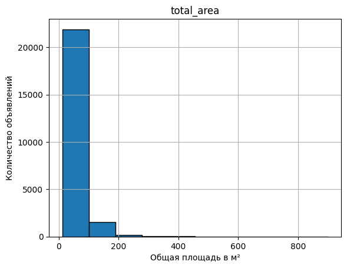

```python
# построим гистограмму с 10 корзинами по умолчанию
plt.hist(data['total_area'], edgecolor='black')

# обозначим заголовок - имя столбца
# назовём оси'y' и 'x'
# добавим сетку
plt.title('total_area')
plt.ylabel('Количество объявлений')
plt.xlabel('Общая площадь в м²')
plt.grid(True)
```

- Гистограмма показывает, что более **20 000** объявлений сосредоточено в диапазоне с общей площадью квартиры приблизительно от `10 до 100 м²`, далее количество резко уменьшается и приближается к `200 м²`. На графике виден длинный ховст. Это значит, что есть объявления с общей площадью более `400 м²`.

Ознакомимся с числовым описанием данных по столбцу `total_area`:

```python
# добавим числовое описание данных с помощью метода describe()
data['total_area'].describe()
```

```
count    23699.000000
mean        60.348651
std         35.654083
min         12.000000
25%         40.000000
50%         52.000000
75%         69.900000
max        900.000000
Name: total_area, dtype: float64
```

- Большинство объявлений сосредоточено в диапазоне от `40` до `69.9 м²`.
- Среднее значение — `60.3` больше медианы — `52`, а стандартное отклонение составляет — `35.6`. Значит, в данных есть серьёзные аномалии или выбросы.
- Минимальное значение выглядит подозрительно — `12 м²`. Нужно посмотреть дополнительную информацию о жилом объекте с такой площадью.
- Максимальное значение в столбце составляет `900 м²`и не отображается на гистограмме выше. Вероятно, в данных есть небольшое количество особенно высоких значений, которые сильно выделяются в наборе данных.

Чтобы увидеть выбросы в данных, построим диаграмму размаха:

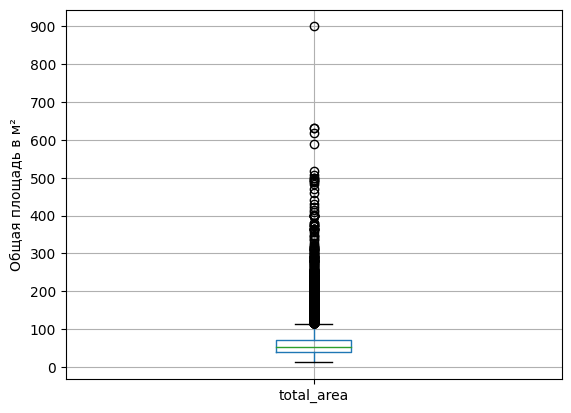

```python
# построим диаграмму размаха по столбцу с помощью метода boxplot()
data.boxplot(column='total_area')

# проставим метки на оси 'y' c шагом 100
plt.yticks(range(0, 901, 100))

# назовём ось 'y'
plt.ylabel('Общая площадь в м²')

# выведем диаграмму на экран
plt.show()
```

- "Ящик с усами" показывает, что выбросы достигают отметки примерно `640 м²`. Также видно особенно крупное значение — `900 м²`.

Ознакомимся с информацией о квартирах с общей площадью — около `12 м²`:

```python
# напишем функцию, которая фильтрует строки в выбранном столбце датафрейма
def filtered_data(column, value_1, value_2):
    return data[(data[column] >= value_1) & (data[column] < value_2)]
```

```python
# вызовем функцию и выведем результат на экран
filtered_data('total_area', 12.0, 12.9)
```

|  | total_images | last_price | total_area | first_day_exposition | rooms | ceiling_height | floors_total | living_area | floor | is_apartment | ... | parks_nearest | ponds_around_3000m | ponds_nearest | days_exposition | price_per_square_meter | weekday_publication | month_publication | year_publication | floor_type | center_distance_km |
| --- | --- | --- | --- | --- | --- | --- | --- | --- | --- | --- | --- | --- | --- | --- | --- | --- | --- | --- | --- | --- | --- |
| 19904 | 4 | 2400000 | 12.0 | 2017-07-19 | 1 | 2.55 | 5 | 10.0 | 2 | False | ... | 886.0 | 2 | 45.0 | 200 | 200000.0 | 2 | 7 | 2017 | Другой | 1.0 |

1 rows × 28 columns

Найден один объект с общей площадью `12 м²` — однокомнатная квартира недалеко от центра. Жилая площадь объекта составляет `10 м²`. Оставшиеся `2 м²`могут представлять собой площадь небольшой комнаты. Несмотря на то, что такие квартиры встречаются редко, значение выглядит реалистично, если учесть дополнительную информацию.

Гистограмма позволяет получить общее понимание распределения данных, но не предоставляет точных числовых границ для выбросов. Межквартильный размах — более надежный и объективный метод.

Определим верхнюю границу выбросов:

```python
# напишем функцию для расчётов с параметром - столбец датафрейма
# вычислим первый (25%) и третий (75%) квартили по столбцу
# вычислим межквартильный размах - IQR
# вычислим верхнюю границу для выбросов
def emission_limit(column):
    Q1 = data[column].quantile(0.25)
    Q3 = data[column].quantile(0.75)
    IQR = Q3 - Q1
    upper_limit = Q3 + 1.5 * IQR
    return f"Верхняя граница выбросов: {upper_limit:.2f}"
```

```python
# выведем результат на экран
print(emission_limit('total_area'))
```

```
Верхняя граница выбросов: 114.75
```

Отфильтруем данные с учетом верхней границы выбросов:

```python
# сохраним копию исходного датафрейма в good_data
good_data = data.copy()

# отфильтруем данные с помощью guery() и сохраним результат в good_data
good_data = good_data.query('total_area <= 114.75')

# проверим результат, выведем первые 10 строк столбца датафрейма, отсортированных по убыванию
good_data['total_area'].sort_values(ascending=False).head(10)
```

```
20809    114.60
12831    114.60
18273    114.55
16094    114.50
1966     114.40
13686    114.30
19491    114.30
20477    114.20
5978     114.20
1170     114.20
Name: total_area, dtype: float64
```

Чтобы наглядно сравнить результат предобработки, наложим гистограмму исходных данных на гистограмму очищенных данных:

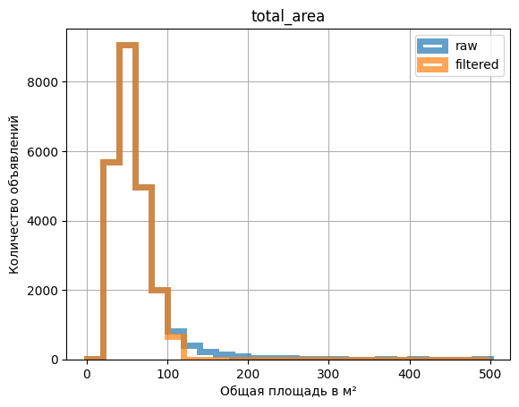

```python
# построим гистограммы на основе исходных данных
ax = data.plot(
    kind='hist',
    y='total_area',
    histtype='step',
    range=(0, 500),
    bins=25,
    linewidth=5,
    alpha=0.7,
    label='raw',
)
# накладываем на гистограмму после предобработки данных
good_data.plot(
    kind='hist',
    y='total_area',
    histtype='step',
    range=(0, 500),
    bins=25,
    linewidth=5,
    alpha=0.7,
    label='filtered',
    ax=ax,
    grid=True,
    legend=True,
)

# дадим название графику и осям
ax.set_title('total_area')
ax.set_xlabel('Общая площадь в м²')
ax.set_ylabel('Количество объявлений')
```

**Вывод:**

1. Большинство объявлений имеют площадь от 40 до 69.9 м², но в данных присутствуют выбросы до 640 м², а также особенно крупная квартира — 900 м².
2. После фильтрации данных распределение стало более концентрированным. Это позволит избежать искажений при дальнейшем анализе.

#### Изучение жилой площади

Рассмотрим гистограмму по столбцу `living_area` с жилой площадью более детально:

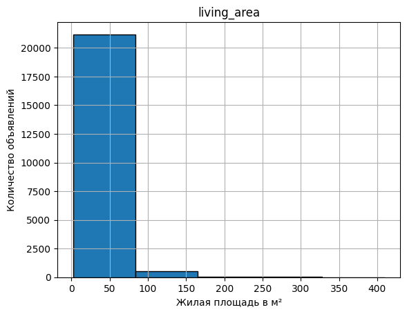

```python
# построим гистограмму с 5 корзинами
plt.hist(data['living_area'], bins=5, edgecolor='black')

# обозначим заголовок - имя столбца
# назовём оси'y' и 'x'
# добавим сетку
plt.title('living_area')
plt.ylabel('Количество объявлений')
plt.xlabel('Жилая площадь в м²')
plt.grid(True)
```

- Более **20 000** объявлений сосредоточено в диапазоне с жилой площадью квартир приблизительно `от 3 до 80 м²`, далее количество резко уменьшается и приближается примерно к `160 м²`.
- На графике виден тонкий хвост до `325 м²`. Значит, что в таблице есть небольшое количество объявлений с такой жилой площадью.

Ознакомимся с числовым описанием данных по столбцу `living_area`:

```python
# добавим числовое описание данных с помощью метода describe()
data['living_area'].describe()
```

```
count    21796.000000
mean        34.457852
std         22.030445
min          2.000000
25%         18.600000
50%         30.000000
75%         42.300000
max        409.700000
Name: living_area, dtype: float64
```

- Большинство объявлений находится в диапазоне от `18.6` до `42.3 м²`.
- Среднее значение — **34.4** больше медианы — **30**. Достаточно высокое стандартное отклонение — **22**. Значит, в данных есть серьёзные аномалии или выбросы.
- Подозрительно выглядят минимальное и максимальное значения — `2 м²` и `409.7 м²`.

Чтобы увидеть выбросы в данных, построим диаграмму размаха:

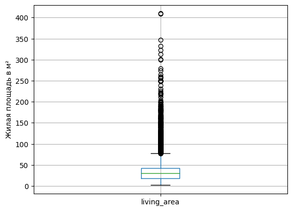

```python
# построим диаграммы размаха по столбцу с помощью метода boxplot()
data.boxplot(column='living_area')

# назовём ось 'y'
plt.ylabel('Жилая площадь в м²')
```

- "Ящик с усами" показывает, что выбросы достигают отметки `350 м²`. Также видно особенно крупное значение — `409.7 м²`.

Обычно минимальная жилая площадь составляет хотя бы 10 м². Например, в квартире с минимальной общей площадью 12 м² жилая площадь может составить 10 м². Вероятно, квартиры с жилой площадью от `2` до `10 м²` являются аномалиями.

Чтобы проверить это предположение, ознакомимся с общей информацией о таких квартирах:

```python
# вызовем функцию и выведем результат на экран
filtered_data('living_area', 2.0, 10.0)
```

|  | total_images | last_price | total_area | first_day_exposition | rooms | ceiling_height | floors_total | living_area | floor | is_apartment | ... | parks_nearest | ponds_around_3000m | ponds_nearest | days_exposition | price_per_square_meter | weekday_publication | month_publication | year_publication | floor_type | center_distance_km |
| --- | --- | --- | --- | --- | --- | --- | --- | --- | --- | --- | --- | --- | --- | --- | --- | --- | --- | --- | --- | --- | --- |
| 114 | 5 | 4000000 | 21.40 | 2019-02-07 | 1 | 2.90 | 8 | 8.3 | 7 | False | ... | 488.0 | 1 | 286.0 | 95 | 186915.89 | 3 | 2 | 2019 | Другой | 6.0 |
| 680 | 14 | 7200000 | 43.00 | 2017-10-31 | 1 | NaN | 8 | 9.0 | 2 | False | ... | 2137.0 | 1 | 933.0 | 296 | 167441.86 | 1 | 10 | 2017 | Другой | 5.0 |
| 1326 | 8 | 8100000 | 52.00 | 2017-01-29 | 2 | 2.70 | 25 | 9.0 | 15 | False | ... | NaN | 1 | 1180.0 | 337 | 155769.23 | 6 | 1 | 2017 | Другой | 16.0 |
| 2309 | 10 | 4200000 | 62.40 | 2017-06-15 | 2 | 2.60 | 9 | 8.4 | 6 | False | ... | NaN | 0 | NaN | 111 | 67307.69 | 3 | 6 | 2017 | Другой | 29.0 |
| 3242 | 7 | 4440000 | 41.00 | 2017-07-02 | 1 | NaN | 17 | 3.0 | 17 | False | ... | NaN | 0 | NaN | 216 | 108292.68 | 6 | 7 | 2017 | Последний | 13.0 |
| 4100 | 17 | 5300000 | 34.80 | 2017-06-19 | 1 | 2.70 | 23 | 9.0 | 15 | False | ... | NaN | 0 | NaN | 30 | 152298.85 | 0 | 6 | 2017 | Другой | 13.0 |
| 4542 | 12 | 3300000 | 18.00 | 2018-11-07 | 1 | 3.50 | 5 | 9.0 | 2 | False | ... | 349.0 | 1 | 963.0 | 9 | 183333.33 | 2 | 11 | 2018 | Другой | 5.0 |
| 7312 | 8 | 3400000 | 27.00 | 2018-02-21 | 2 | 2.50 | 15 | 9.0 | 4 | False | ... | 617.0 | 0 | NaN | 95 | 125925.93 | 2 | 2 | 2018 | Другой | 16.0 |
| 8325 | 9 | 4800000 | 52.00 | 2017-10-25 | 2 | NaN | 5 | 9.0 | 2 | False | ... | NaN | 2 | 118.0 | 119 | 92307.69 | 2 | 10 | 2017 | Другой | 13.0 |
| 13915 | 20 | 6350000 | 52.00 | 2018-02-06 | 2 | 3.00 | 6 | 2.0 | 2 | False | ... | NaN | 1 | 1012.0 | 91 | 122115.38 | 1 | 2 | 2018 | Другой | 7.0 |
| 15833 | 20 | 4600000 | 33.00 | 2017-01-01 | 1 | 2.70 | 22 | 9.0 | 12 | False | ... | NaN | 0 | NaN | 511 | 139393.94 | 6 | 1 | 2017 | Другой | 14.0 |
| 16431 | 13 | 3799000 | 31.00 | 2018-04-12 | 1 | 2.60 | 5 | 6.0 | 1 | False | ... | 430.0 | 0 | NaN | 168 | 122548.39 | 3 | 4 | 2018 | Первый | 5.0 |
| 17248 | 20 | 5300000 | 33.00 | 2017-04-14 | 1 | 2.70 | 22 | 8.9 | 16 | False | ... | NaN | 0 | NaN | 216 | 160606.06 | 4 | 4 | 2017 | Другой | 14.0 |
| 17582 | 11 | 2680000 | 22.00 | 2018-08-11 | 0 | NaN | 25 | 5.0 | 8 | False | ... | 835.0 | 1 | 652.0 | 70 | 121818.18 | 5 | 8 | 2018 | Другой | 12.0 |
| 19251 | 19 | 4050000 | 33.00 | 2018-10-15 | 1 | 2.50 | 22 | 6.5 | 21 | False | ... | 458.0 | 0 | NaN | 44 | 122727.27 | 0 | 10 | 2018 | Другой | 11.0 |
| 19620 | 10 | 4300000 | 33.00 | 2018-02-01 | 1 | NaN | 5 | 9.0 | 1 | False | ... | 251.0 | 3 | 220.0 | 86 | 130303.03 | 3 | 2 | 2018 | Первый | 3.0 |
| 20994 | 7 | 8900000 | 50.60 | 2018-10-22 | 2 | 2.50 | 7 | 8.0 | 3 | False | ... | 173.0 | 3 | 126.0 | 95 | 175889.33 | 0 | 10 | 2018 | Другой | 8.0 |
| 21505 | 9 | 4100000 | 35.30 | 2018-01-10 | 1 | 2.75 | 27 | 8.5 | 11 | False | ... | NaN | 0 | NaN | 60 | 116147.31 | 2 | 1 | 2018 | Другой | 15.0 |
| 21758 | 0 | 2330000 | 23.00 | 2018-01-01 | 0 | NaN | 24 | 2.0 | 22 | False | ... | NaN | <NA> | NaN | 66 | 101304.35 | 0 | 1 | 2018 | Другой | NaN |
| 21908 | 9 | 5300000 | 46.30 | 2018-03-20 | 1 | 2.75 | 7 | 9.8 | 3 | False | ... | NaN | 1 | 1144.0 | 36 | 114470.84 | 1 | 3 | 2018 | Другой | 32.0 |
| 21943 | 15 | 6100000 | 77.60 | 2019-02-28 | 4 | 2.50 | 9 | 5.4 | 1 | False | ... | 584.0 | 0 | NaN | 33 | 78608.25 | 3 | 2 | 2019 | Первый | 11.0 |
| 22252 | 4 | 3340000 | 37.40 | 2018-02-08 | 1 | 2.80 | 8 | 9.0 | 4 | False | ... | 365.0 | 0 | NaN | 233 | 89304.81 | 3 | 2 | 2018 | Другой | 19.0 |
| 22473 | 0 | 3490304 | 33.26 | 2015-12-22 | 2 | NaN | 13 | 9.1 | 9 | False | ... | NaN | 0 | NaN | 199 | 104939.99 | 1 | 12 | 2015 | Другой | 13.0 |
| 23208 | 12 | 4800000 | 37.00 | 2016-02-24 | 1 | NaN | 14 | 8.0 | 11 | False | ... | 358.0 | 1 | 950.0 | 139 | 129729.73 | 2 | 2 | 2016 | Другой | 12.0 |
| 23574 | 14 | 64990000 | 139.00 | 2015-11-24 | 3 | 3.00 | 8 | 3.0 | 8 | False | ... | 630.0 | 3 | 100.0 | 280 | 467553.96 | 1 | 11 | 2015 | Последний | 6.0 |

25 rows × 28 columns

Трудно назвать правдоподобным соотношение жилой и общей площади некоторых квартир. Например, согласно таблице, доля жилой площади — `3 м²` от общей площади — `139 м²` составляет **2.16%**. Сомнения вызывает также количество комнат в квартирах с малой жилой площадью. Например, нереалистично выглядит квартира с общей и жилой площадью — `77.6` и `5.4 м²` и **4** комнатами.

Значит, квартиры с жилой площадью до `10 м²` являются аномалиями и их нужно удалить из датафрейма.

Определим верхнюю границу выбросов с помощью межквартильного размаха:

```python
# выведем результат на экран
print(emission_limit('living_area'))
```

```
Верхняя граница выбросов: 77.85
```

Отфильтруем данные в столбце с учётом аномальных минимальных значений и верхней границы выбросов:

```python
# отфильтруем данные с помощью guery() и сохраним результат в good_data
good_data = good_data.query('living_area >= 10.0 and living_area <= 77.85')

# проверим результат, выведем первые 10 строк столбца датафрейма, отсортированных по убыванию
good_data['living_area'].sort_values(ascending=False).head(10)
```

```
9672     77.8
7620     77.4
18239    77.0
7398     77.0
3155     77.0
4575     77.0
1308     77.0
14602    77.0
315      76.9
6106     76.8
Name: living_area, dtype: float64
```

```python
# проверим результат, выведем первые 10 строк столбца датафрейма, отсортированных по возрастанию
good_data['living_area'].sort_values().head(10)
```

```
10291    10.0
7829     10.0
10319    10.0
18278    10.0
10439    10.0
12387    10.0
12177    10.0
8086     10.0
7460     10.0
23359    10.0
Name: living_area, dtype: float64
```

Посмотрим на результат очистки данных:

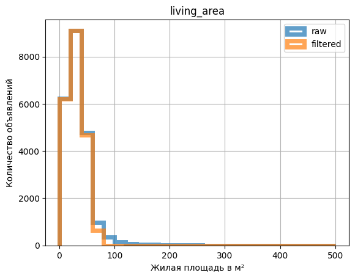

```python
# построим гистограммы на основе исходных данных
ax_2 = data.plot(
    kind='hist',
    y='living_area',
    histtype='step',
    range=(0, 500),
    bins=25,
    linewidth=5,
    alpha=0.7,
    label='raw',
)
# накладываем на гистограмму после предобработки данных
good_data.plot(
    kind='hist',
    y='living_area',
    histtype='step',
    range=(0, 500),
    bins=25,
    linewidth=5,
    alpha=0.7,
    label='filtered',
    ax=ax_2,
    grid=True,
    legend=True,
)

# дадим название графику и осям
ax_2.set_title('living_area')
ax_2.set_xlabel('Жилая площадь в м²')
ax_2.set_ylabel('Количество объявлений')
```

**Вывод:**

1. Гистограмма показывает, что большая часть объявлений относится к квартирам с жилой площадью от 3 до 80 м². Однако встречаются выбросы до 350 м² и особенно крупное значение — 409.7 м².
2. Анализ показал, что данные содержат аномалии — квартиры с жилой площадью менее 10 м².
3. После фильтрации выбросов гистограмма сгладилась, и данные стали более репрезентативными.

#### Изучение площади кухни

Рассмотрим гистограмму по столбцу `kitchen_area` с площадью кухни более детально:

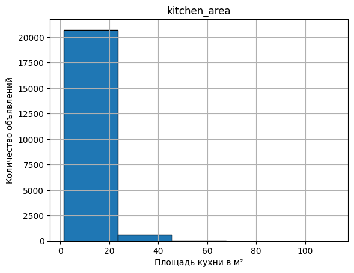

```python
# # построим гистограмму с 5 корзинами
plt.hist(data['kitchen_area'], bins=5, edgecolor='black')

# обозначим заголовок - имя столбца
# назовём оси'y' и 'x'
# добавим сетку
plt.title('kitchen_area')
plt.ylabel('Количество объявлений')
plt.xlabel('Площадь кухни в м²')
plt.grid(True)
```

- Более **20 000** объявлений сосредоточено в диапазоне с площадью кухни приблизительно `от 3 до 22 м²`.
- Далее количество резко уменьшается и приближается примерно к `45 м²`.
- Виден длинный тонкий хвост примерно до `68 м²`. Значит, есть небольшое количество объявлений с площадью кухни до этой отметки.

Ознакомимся с числовым описанием данных столбца:

```python
data['kitchen_area'].describe()
```

```
count    21421.000000
mean        10.569807
std          5.905438
min          1.300000
25%          7.000000
50%          9.100000
75%         12.000000
max        112.000000
Name: kitchen_area, dtype: float64
```

- Большинство объявлений сосредоточено в диапазоне от `7` до `12 м²`.
- Среднее значение — `10.5` больше медианы — `9.1`. Стандартное отклонение — `5.9`. В данных есть аномалии или выбросы.
- Сомнения вызывают минимальное и максимальное значения — `1.3 м²` и `112 м²`.

Чтобы увидеть выбросы в данных, построим диаграмму размаха:

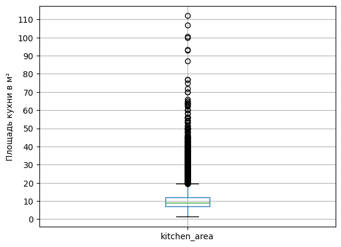

```python
# построим диаграмму размаха по столбцу с помощью метода boxplot()
data.boxplot(column='kitchen_area')

# проставим метки на оси 'y' c шагом 10
plt.yticks(range(0, 113, 10))

# назовём ось 'y'
plt.ylabel('Площадь кухни в м²')

#отобразим диаграмму
plt.show()
```

- Диаграмма показывает, что выбросы достигают максимального значения `112 м²`.

Посмотрим информацию о квартирах с маленькой площадью кухни от `1` до `5 м²`.

Так как колонка `kitchen_area` не отображается при вызове фильтрующей функции и выводе всего датафрейма на экран из-за большого количества столбцов, отфильтруем данные и выведем только нужные колонки:

```python
# отфильтруем информацию в столбце и сохраним результат в переменную data_filtered_kitchen
data_filtered_kitchen = data[(data['kitchen_area'] >= 1.0) & (data['kitchen_area'] < 5.0)]

# выберем нужные столбцы и отобразим результат в порядке возрастания
data_filtered_kitchen[['last_price', 'total_area', 'rooms', 'living_area', 'kitchen_area']].sort_values(by='kitchen_area')
```

|  | last_price | total_area | rooms | living_area | kitchen_area |
| --- | --- | --- | --- | --- | --- |
| 20217 | 4250000 | 28.50 | 1 | 19.5 | 1.3 |
| 19642 | 1190000 | 14.00 | 1 | 11.0 | 2.0 |
| 16367 | 2720000 | 25.70 | 1 | 22.6 | 2.0 |
| 9138 | 2920000 | 23.29 | 1 | 21.0 | 2.0 |
| 906 | 2600000 | 27.00 | 1 | 18.0 | 2.0 |
| ... | ... | ... | ... | ... | ... |
| 2653 | 3680000 | 43.00 | 2 | 27.9 | 4.9 |
| 2484 | 4900000 | 55.20 | 3 | 40.5 | 4.9 |
| 1327 | 2650000 | 46.20 | 2 | 29.2 | 4.9 |
| 17683 | 3700000 | 40.80 | 2 | 27.2 | 4.9 |
| 23678 | 3500000 | 43.00 | 2 | 26.1 | 4.9 |

105 rows × 5 columns

Информация о квартирах выглядит неправдоподобно. Например, сомнения вызывает однокомнатная квартира, где кухня занимает всего лишь `1.3 м²` при общей и жилой площади `28.50 м²`и `19.5 м²`.

Нетипично маленькие кухни встречаются даже в крупных квартирах. Например, кухня с площадью `4.9 м²` в трёхкомнатной квартире с общей и жилой площадью `55.20 м²`и `40.5 м²`.

Значит, квартиры с площадью кухни меньше `5 м²` являются аномалиями. Исключим их, чтобы получить более корректные выводы.

Попробуем определить верхнюю границу выбросов:

```python
# выведем результат на экран
print(emission_limit('kitchen_area'))
```

```
Верхняя граница выбросов: 19.50
```

Это значение выглядит правдоподобно и является оптимальным размером кухни с логической точки зрения.

Отфильтруем данные в столбце c учётом аномальных минимальных значений и верхней границы выбросов:

```python
# отфильтруем данные с помощью guery() и сохраним результат в good_data
good_data = good_data.query('kitchen_area >= 5.0 and kitchen_area <= 19.50')

# проверим результат, выведем первые 10 строк столбца датафрейма, отсортированных по убыванию
good_data['kitchen_area'].sort_values(ascending=False).head(10)
```

```
8983     19.50
1183     19.50
11048    19.50
475      19.50
8286     19.42
9723     19.40
15365    19.40
8901     19.40
12138    19.39
6343     19.35
Name: kitchen_area, dtype: float64
```

```python
# проверим результат, выведем первые 10 строк столбца датафрейма, отсортированных по возрастанию
good_data['kitchen_area'].sort_values().head(10)
```

```
11825    5.0
11951    5.0
14128    5.0
6203     5.0
6213     5.0
17886    5.0
2308     5.0
22461    5.0
2284     5.0
402      5.0
Name: kitchen_area, dtype: float64
```

Посмотрим на результат очистки данных:

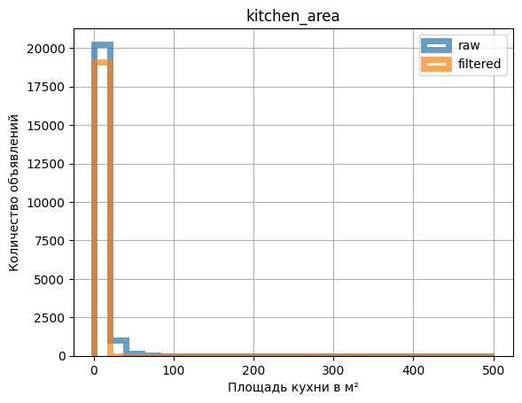

```python
# построим гистограммы на основе исходных данных
ax_3 = data.plot(
    kind='hist',
    y='kitchen_area',
    histtype='step',
    range=(0, 500),
    bins=25,
    linewidth=5,
    alpha=0.7,
    label='raw',
)
# накладываем на гистограмму после предобработки данных
good_data.plot(
    kind='hist',
    y='kitchen_area',
    histtype='step',
    range=(0, 500),
    bins=25,
    linewidth=5,
    alpha=0.7,
    label='filtered',
    ax=ax_3,
    grid=True,
    legend=True,
)

# дадим название графику и осям
ax_3.set_title('kitchen_area')
ax_3.set_xlabel('Площадь кухни в м²')
ax_3.set_ylabel('Количество объявлений')
```

**Вывод:**

1. Большинство объявлений сосредоточено в диапазоне `7–12 м²`.
2. Данные содержат аномалии: кухни меньше `5 м²` и выбросы свыше `19.5 м²`.
3. Очистка данных позволила устранить нереалистичные значения, что подтверждается изменением распределения на гистограмме.

#### Изучение цены объекта

Рассмотрим гистограмму по столбцу `last_price` с ценой объектов более детально:

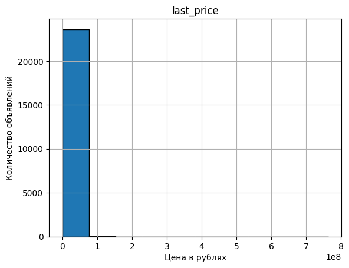

```python
# построим гистограмму с 10 корзинами по умолчанию
plt.hist(data['last_price'], edgecolor='black')

# обозначим имя столбца
# назовём оси 'x' и 'y'
# добавим сетку
plt.title('last_price')
plt.xlabel('Цена в рублях')
plt.ylabel('Количество объявлений')
plt.grid(True)
```

- На оси абсцисс находятся значения в сотнях миллионов рублей. Например, `1 — 100 000 000`, `2 — 200 000 000` и далее до `800 000 000`.
- Большинство значений сосредоточено в первом интервале, примерно до `75 000 000`.
- Заметен небольшой хвост, тянущийся до середины второго интервала, приблизительно до `150 000 000`.

Проверим точное количество объявлений в каждом интервале:

```python
# сохраним список с ценами в 8 интервалах в переменную prices
prices = [0, 100_000_000, 200_000_000, 300_000_000, 400_000_000,
       500_000_000, 600_000_000, 700_000_000, 800_000_000]

# напишем функцию со списком prices в качестве параметра
# создадим пустой список counts для количества объявлений в каждом интервале
# напишем в заголовке цикла len(prices) - 1, чтобы избежать выход за пределы списка
# создадим в теле цикла переменные price_1 и price_2
# в price_2 сохраним prices[i + 1], чтобы использовать следущющий элемент списка
# сделаем срез по столбцу датафрейма с помощью query(), передадим методу внешние переменные, чтобы использовать цены из списка
# сохраним в список counts результаты расчётов - количество объявлений в датафрейме для каждого диапазона
# вернём список
def last_price_query(prices):
    counts = []
    for i in range(len(prices) - 1):
        price_1 = prices[i]
        price_2 = prices[i + 1]
        data_query = data.query('@price_1 <= last_price <= @price_2')
        counts.append(data_query['last_price'].count())

    return counts

# вызовем функцию и выведем результат
print(last_price_query(prices))
```

```
[23662, 28, 5, 2, 2, 0, 0, 1]
```

Рассмотрим числовое описание данных столбца `last_price`:

```python
# добавим числовое описание данных с помощью метода describe()
data['last_price'].describe()
```

```
count            23699.0
mean      6541548.771552
std      10887013.267545
min              12190.0
25%            3400000.0
50%            4650000.0
75%            6800000.0
max          763000000.0
Name: last_price, dtype: Float64
```

Построим диаграмму размаха, чтобы увидеть возможные выбросы в данных:

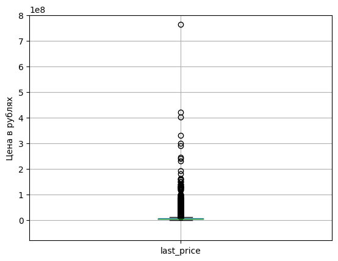

```python
# построим диаграмму размаха по столбцу с помощью метода boxplot()
data.boxplot(column='last_price')

# установим диапазон для оси 'y'
plt.ylim(-80_000_000, 800_000_000)

# назовём ось 'y'
plt.ylabel('Цена в рублях')

# выведем диаграмму на экран
plt.show()
```

- Видны выбросы до `400 000 000` , а также одно особенно крупное значение — `763 000 000`.

Посмотрим информацию о квартирах с минимальной ценой в диапазоне — `от 12 190 до 400 000 рублей`:

```python
filtered_data('last_price', 12_190, 400_000)
```

|  | total_images | last_price | total_area | first_day_exposition | rooms | ceiling_height | floors_total | living_area | floor | is_apartment | ... | parks_nearest | ponds_around_3000m | ponds_nearest | days_exposition | price_per_square_meter | weekday_publication | month_publication | year_publication | floor_type | center_distance_km |
| --- | --- | --- | --- | --- | --- | --- | --- | --- | --- | --- | --- | --- | --- | --- | --- | --- | --- | --- | --- | --- | --- |
| 8793 | 7 | 12190 | 109.0 | 2019-03-20 | 2 | 2.75 | 25 | 32.0 | 25 | False | ... | 805.0 | 0 | NaN | 8 | 111.83 | 2 | 3 | 2019 | Последний | 9.0 |

1 rows × 28 columns

Найден всего один объект с ценой `12 190 рублей` — двухкомнатная квартира в многоэтажном доме с общей площадью `109 м²` и жилой площадью `32 м²`. Это значение — явная ошибка, так как такая цена для подобного объекта нереалистична.

Будем считать квартиры дешевле `2 000 000 рублей` аномалиями, потому что на рынке Петербурга такие цены маловероятны. Скорее всего, это либо ошибки, либо особые случаи: доли в квартире, жильё без ремонта или объекты за городом.

Определим границу нормального размаха с помощью расчетов:

```python
# выведем результат на экран
print(emission_limit('last_price'))
```

```
Верхняя граница выбросов: 11900000.00
```

Очистим данные от выбросов в столбце `last_price`:

```python
# отфильтруем данные с помощью guery() и сохраним результат в good_data
good_data = good_data.query('last_price >= 2_000_000 and last_price <= 11_900_000')

# проверим результат, выведем первые 10 строк столбца датафрейма, отсортированных по убыванию
good_data['last_price'].sort_values(ascending=False).head(10)
```

```
3491     11900000
8405     11900000
9568     11900000
23343    11900000
7823     11900000
3865     11900000
13969    11900000
22300    11900000
22275    11900000
18229    11900000
Name: last_price, dtype: Int64
```

```python
# проверим результат, выведем первые 10 строк столбца датафрейма, отсортированных по возрастанию
good_data['last_price'].sort_values().head(10)
```

```
15941    2000000
16611    2000000
16758    2000000
4107     2000000
15091    2000000
7151     2000000
275      2000000
1657     2000000
6148     2000000
15154    2000000
Name: last_price, dtype: Int64
```

Посмотрим на результат очистки данных:

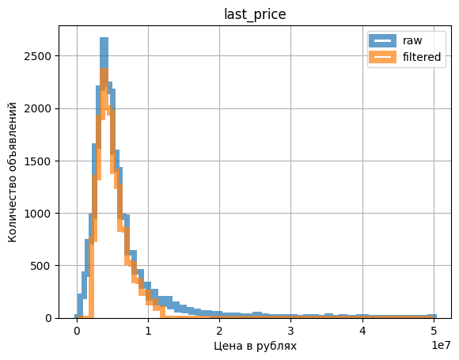

```python
# построим гистограммы на основе исходных данных
ax_4 = data.plot(
    kind='hist',
    y='last_price',
    histtype='step',
    range=(0, 50_000_000),
    bins=100,
    linewidth=5,
    alpha=0.7,
    label='raw',
)
# накладываем на гистограмму после предобработки данных
good_data.plot(
    kind='hist',
    y='last_price',
    histtype='step',
    range=(0, 50_000_000),
    bins=100,
    linewidth=5,
    alpha=0.7,
    label='filtered',
    ax=ax_4,
    grid=True,
    legend=True,
)

# дадим название графику и осям
ax_4.set_title('last_price')
ax_4.set_xlabel('Цена в рублях')
ax_4.set_ylabel('Количество объявлений')
```

**Вывод:**

1. Большинство объявлений сосредоточено в диапазоне до 75 000 000 рублей, а далее количество резко сокращается.
2. В данных выявлены выбросы, включая объекты с нереалистично низкой — 12 190 рублей и экстремально высокой ценой — 763 000 000 рублей.
3. Для более корректного анализа были отфильтрованы объявления с ценами ниже 2 000 000 и выше 11 900 000 рублей.
4. Очистка данных привела к более точному распределению цен.

#### Изучение количества комнат

Рассмотрим гистограмму по столбцу `rooms` с количеством комнат более детально:

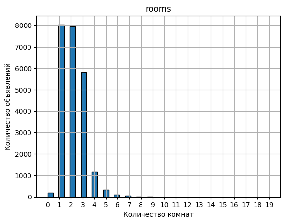

```python
# построим гистограмму с 40 корзинами
plt.hist(data['rooms'], bins=40, edgecolor='black')

# обозначим имя столбца
# назовём оси 'x' и 'y'
# ограничим ось 'x' значениями от 0 до 20
# добавим сетку
plt.title('rooms')
plt.xlabel('Количество комнат')
plt.ylabel('Количество объявлений')
plt.xticks(range(0, 20))
plt.grid(True)
```

- Наибольшее количество объявлений в наборе данных приходится на `однокомнатные` квартиры. За ними следуют `двухкомнатные` и `трёхкомнатные`. На гистограмме заметно, что изредка встречаются квартиры с `7`, `8` и `9` комнатами.

Ознакомимся с числовым описанием данных:

```python
# выведем числовое описание с помощью метода describe()
data['rooms'].describe()
```

```
count    23699.000000
mean         2.070636
std          1.078405
min          0.000000
25%          1.000000
50%          2.000000
75%          3.000000
max         19.000000
Name: rooms, dtype: float64
```

- Среднее значение практически совпадает с медианой. Стандартное отклонение показывает, что значения в списке отличаются от среднего на **1**. В распределении есть аномалии.
- Минимальное значение, равное `0`, соответствует квартирам-студиям. Максимальное значение вызывает сомнения, однако теоретически возможно. Жилые объекты с `19` комнатами могут представлять собой элитную недвижимость.

Выведем дополнительную информацию о квартирах с `19` комнатами:

```python
# выведем результат на экран
filtered_data('rooms', 19, 20)
```

|  | total_images | last_price | total_area | first_day_exposition | rooms | ceiling_height | floors_total | living_area | floor | is_apartment | ... | parks_nearest | ponds_around_3000m | ponds_nearest | days_exposition | price_per_square_meter | weekday_publication | month_publication | year_publication | floor_type | center_distance_km |
| --- | --- | --- | --- | --- | --- | --- | --- | --- | --- | --- | --- | --- | --- | --- | --- | --- | --- | --- | --- | --- | --- |
| 14498 | 6 | 32250000 | 374.6 | 2018-06-09 | 19 | NaN | 5 | 264.5 | 2 | False | ... | NaN | 2 | 548.0 | 114 | 86091.83 | 5 | 6 | 2018 | Другой | 4.0 |

1 rows × 28 columns

Найдена одна квартира с 19 комнатами. Жилая площадь объекта составляет 70,6% от общей, что может свидетельствовать о наличии вспомогательных помещений, таких как гостиные, столовые, кабинеты. Подобные объекты встречаются в элитном сегменте рынка недвижимости.

Посмотрим, сколько квартир с разным количеством комнат представлено в датафрейме:

```python
# выберем столбец и посмотрим количество уникальных значений
data['rooms'].value_counts()
```

```
rooms
1     8047
2     7940
3     5814
4     1180
5      326
0      197
6      105
7       59
8       12
9        8
10       3
11       2
14       2
15       1
19       1
16       1
12       1
Name: count, dtype: int64
```

Квартиры с большим количеством комнат являются единичными случаями: например, в наборе данных есть всего **1** квартира с `19` комнатами, **1** с `16`, **1** с `15` и далее. Их наличие может исказить статистические показатели, например, цены на квадратный метр.

Лучше исключить такие редкие значения из анализа, чтобы избежать некорректных результатов.

Рассчитаем границу нормального размаха:

```python
# вызовем функцию и выведем результат на экран
print(emission_limit('rooms'))
```

```
Верхняя граница выбросов: 6.00
```

Верхняя граница выглядит реалистично и соответствует оптимальному количеству комнат с логической точки зрения.

Очистим данные от выбросов:

```python
# отфильтруем данные с помощью guery() и сохраним результат в good_data
good_data = good_data.query('rooms <= 6')

# проверим результат, выведем первые 10 строк столбца датафрейма, отсортированных по убыванию
good_data['rooms'].sort_values(ascending=False).head(10)
```

```
5255     6
23047    6
14510    6
9277     5
5206     5
495      5
12200    5
20893    5
20398    5
9789     5
Name: rooms, dtype: int64
```

Посмотрим на результат очистки данных:

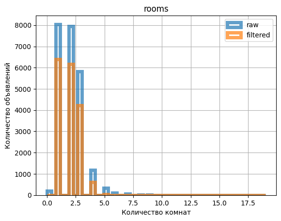

```python
# построим гистограммы на основе исходных данных
ax_5 = data.plot(
    kind='hist',
    y='rooms',
    histtype='step',
    range=(0, 19),
    bins=50,
    linewidth=5,
    alpha=0.7,
    label='raw',
)
# накладываем на гистограмму после предобработки данных
good_data.plot(
    kind='hist',
    y='rooms',
    histtype='step',
    range=(0, 19),
    bins=50,
    linewidth=5,
    alpha=0.7,
    label='filtered',
    ax=ax_5,
    grid=True,
    legend=True,
)

# дадим название графику и осям
ax_5.set_title('rooms')
ax_5.set_xlabel('Количество комнат')
ax_5.set_ylabel('Количество объявлений')
```

**Вывод:**

1. В основном, в датафрейме представлены однокомнатные квартиры.
2. Объявления со значениями выше 6 комнат встречаются крайне редко и могут искажать статистику, поэтому исключили их из анализа.

#### Изучение высоты потолков

Рассмотрим гистограмму по столбцу `ceiling_height` с высотой потолков более детально:

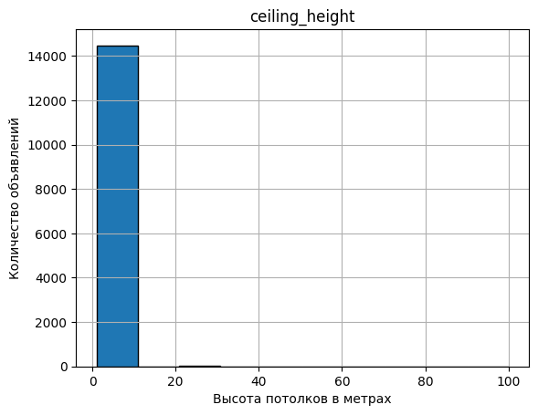

```python
# построим гистограмму с 10 корзинами по умолчанию
plt.hist(data['ceiling_height'], edgecolor='black')

# обозначим имя столбца
# назовём оси 'x' и 'y'
# добавим сетку
# выведем гистограмму
plt.title('ceiling_height')
plt.xlabel('Высота потолков в метрах')
plt.ylabel('Количество объявлений')
plt.grid(True)
```

- В данных представлено более 14 000 квартир с размером потолков в диапазоне примерно до 9 метров. Также встречаются единичные значения в диапазоне от 20 до 26 метров. Данные выглядят нереалистично и, вероятно, являются аномалиями.

Ознакомимся с числовым описанием данных:

```python
# выведем числовое описание с помощью метода describe()
data['ceiling_height'].describe()
```

```
count    14504.000000
mean         2.771499
std          1.261056
min          1.000000
25%          2.520000
50%          2.650000
75%          2.800000
max        100.000000
Name: ceiling_height, dtype: float64
```

- Основная масса значений находится в диапазоне `2.5 — 2.8 метров`, что соответствует стандартным потолкам в жилых квартирах.
- Среднее значение — **2.7** близко к медиане — **2.6**, что указывает на относительно симметричное распределение. Однако стандартное отклонение — **1.2** довольно высокое, что свидетельствует о наличии выбросов.
- Сомнения вызывают минимальное значение — `1` и максимальное — `100 метров`.

Чтобы увидеть выбросы в данных, построим диаграмму размаха:

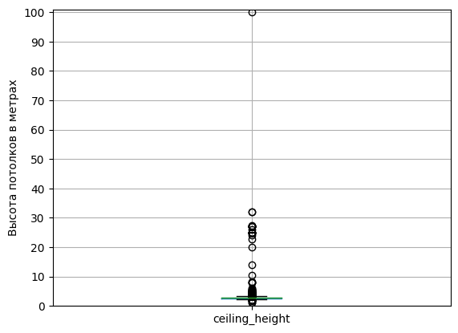

```python
# построим диаграмму размаха по столбцу с помощью метода boxplot()
data.boxplot(column='ceiling_height')

# ограничим диапазон оси 'y'
# проставим метки на оси 'y' c шагом 10
plt.ylim(0, 101)
plt.yticks(range(0, 101, 10))

# назовём ось 'y'
plt.ylabel('Высота потолков в метрах')

# выведем диаграмму
plt.show()
```

- Видны выбросы примерно до `32 метров`, а также одно особенно крупное значение — `100 метров`.

Ознакомимся со списком уникальных значений столбца:

```python
# выберем столбец и выведем список уникальных значений с помощью unique()
data['ceiling_height'].unique()
```

```
array([  2.7 ,    nan,   3.03,   2.5 ,   2.67,   2.56,   3.05,   2.75,
         2.6 ,   2.9 ,   2.8 ,   2.55,   3.  ,   2.65,   3.2 ,   2.61,
         3.25,   3.45,   2.77,   2.85,   2.64,   2.57,   4.15,   3.5 ,
         3.3 ,   2.71,   4.  ,   2.47,   2.73,   2.84,   3.1 ,   2.34,
         3.4 ,   3.06,   2.72,   2.54,   2.51,   2.78,   2.76,  25.  ,
         2.58,   3.7 ,   2.52,   5.2 ,   2.87,   2.66,   2.59,   2.  ,
         2.45,   3.6 ,   2.92,   3.11,   3.13,   3.8 ,   3.15,   3.55,
         3.16,   3.62,   3.12,   2.53,   2.74,   2.96,   2.46,   5.3 ,
         5.  ,   2.79,   2.95,   4.06,   2.94,   3.82,   3.54,   3.53,
         2.83,   4.7 ,   2.4 ,   3.38,   3.01,   5.6 ,   3.65,   3.9 ,
         3.18,   3.35,   2.3 ,   3.57,   2.48,   2.62,   2.82,   3.98,
         2.63,   3.83,   3.52,   3.95,   3.75,   2.88,   3.67,   3.87,
         3.66,   3.85,   3.86,   4.19,   3.24,   4.8 ,   4.5 ,   4.2 ,
         3.36,  32.  ,   3.08,   3.68,   3.07,   3.37,   3.09,   8.  ,
         3.26,   3.34,   2.81,   3.44,   2.97,   3.14,   4.37,   2.68,
         3.22,   3.27,  27.  ,   4.1 ,   2.93,   3.46,  24.  ,   3.47,
         3.33,   3.63,   3.32,  26.  ,   1.2 ,   8.3 ,   2.98,   2.86,
         3.17,   4.4 ,   3.28,   3.04,   4.45,   5.5 ,   3.84,   3.23,
         3.02,   3.21,   3.43,   3.78,   4.3 ,   3.39,   2.69,   3.31,
         4.65,   3.56,   2.2 ,   3.51,   3.93,   3.42,   2.99,   3.49,
        14.  ,   4.14,   2.91,   3.88,   1.75,   4.25,   3.29,  20.  ,
         2.25,   3.76,   3.69,   6.  ,  22.6 ,   2.89,   3.58,   5.8 ,
        27.5 ,   2.49,   4.9 ,   3.48,  10.3 ,   1.  , 100.  ,   3.59])
```

В данных видны редкие и нереалистичные значения: `14`, `27`, `20`, `100 метров`. Скорее всего, это ошибки, возникшие при вводе значений в систему. Например, пользователь мог случайно пропустить точку.

С логической точки зрения признаем выбросами значения ниже `2.5 метров`.

Исправим данные там, где это возможно. Заменим часть значений в столбце:

```python
# создадим словарь со старыми и новыми значениями
values_to_replace = {
    27.5:2.75,
    32.:3.2,
    27.:2.7,
    26.:2.6,
    25.:2.5,
}

# заменим значения в столбце ceiling_height по словарю
good_data['ceiling_height'] = good_data['ceiling_height'].replace(values_to_replace)

# выведем список уникальных значений и проверим результат
good_data['ceiling_height'].unique()
```

```
array([  nan,  2.5 ,  2.67,  2.56,  3.05,  2.7 ,  2.75,  2.6 ,  2.9 ,
        2.8 ,  2.55,  3.  ,  2.65,  2.61,  3.2 ,  3.25,  3.45,  2.77,
        2.64,  2.57,  4.15,  2.47,  2.84,  3.1 ,  3.4 ,  2.72,  2.54,
        2.51,  2.78,  2.76,  2.58,  2.52,  3.5 ,  2.66,  2.59,  2.  ,
        2.85,  3.3 ,  2.45,  2.92,  3.13,  3.8 ,  3.15,  3.62,  2.53,
        2.73,  2.46,  2.95,  3.55,  4.06,  2.94,  2.79,  3.7 ,  2.74,
        2.83,  2.4 ,  3.38,  3.01,  3.65,  2.71,  2.3 ,  2.48,  2.62,
        3.57,  2.82,  3.98,  3.12,  2.63,  3.83,  2.88,  4.19,  3.35,
        4.5 ,  3.75,  3.07,  3.37,  3.09,  3.34,  2.81,  3.44,  4.  ,
        4.37,  3.9 ,  3.95,  2.68,  3.46, 24.  ,  3.27,  3.47,  3.63,
        3.33,  3.32,  3.18,  8.3 ,  2.93,  2.86,  3.08,  4.2 ,  3.17,
        3.14,  3.11,  3.67,  3.28,  3.04,  3.66,  3.23,  3.16,  3.02,
        3.21,  2.87,  3.54,  3.6 ,  4.3 ,  4.1 ,  3.39,  3.22,  3.03,
        3.85,  3.93,  3.42,  3.26,  2.97,  3.24, 14.  ,  8.  ,  3.78,
        3.31,  3.88,  1.75,  4.25, 20.  ,  2.25,  3.06,  3.56, 22.6 ,
        2.89,  2.96,  2.69,  2.49,  3.48,  2.98,  1.  ,  3.49,  3.59,
        2.91,  3.36])
```

Очистим данные от нереалистично низких и высоких значений.

Рассчитаем границу нормального размаха:

```python
# вызовем функцию и выведем результат на экран
print(emission_limit('ceiling_height'))
```

```
Верхняя граница выбросов: 3.22
```

Верхняя граница выглядит правдоподобно. Отфильтруем данные в столбце:

```python
# отфильтруем данные с помощью guery() и сохраним результат в good_data
good_data = good_data.query('ceiling_height >= 2.5 and ceiling_height <= 3.22')

# проверим результат, выведем первые 10 строк столбца датафрейма, отсортированных по убыванию
good_data['ceiling_height'].sort_values(ascending=False).head(10)
```

```
11673    3.22
16018    3.22
20323    3.21
9515     3.21
23047    3.20
8312     3.20
14209    3.20
21588    3.20
16389    3.20
8306     3.20
Name: ceiling_height, dtype: float64
```

```python
# проверим результат, выведем первые 10 строк столбца датафрейма, отсортированных по возрастанию
good_data['ceiling_height'].sort_values().head(10)
```

```
9        2.5
11265    2.5
11269    2.5
11286    2.5
11311    2.5
11316    2.5
11326    2.5
11338    2.5
11339    2.5
11340    2.5
Name: ceiling_height, dtype: float64
```

```python
# выведем список уникальных значений и проверим результат
good_data['ceiling_height'].unique()
```

```
array([2.5 , 2.67, 2.56, 3.05, 2.7 , 2.75, 2.6 , 2.9 , 2.8 , 2.55, 3.  ,
       2.65, 2.61, 3.2 , 2.77, 2.64, 2.57, 2.84, 3.1 , 2.72, 2.54, 2.51,
       2.78, 2.76, 2.58, 2.52, 2.66, 2.59, 2.85, 2.92, 3.13, 3.15, 2.53,
       2.73, 2.95, 2.94, 2.79, 2.74, 2.83, 3.01, 2.71, 2.62, 2.82, 3.12,
       2.63, 2.88, 3.07, 3.09, 2.81, 2.68, 3.18, 2.93, 2.86, 3.08, 3.17,
       3.14, 3.11, 3.04, 3.16, 3.02, 3.21, 2.87, 3.22, 3.03, 2.97, 3.06,
       2.89, 2.96, 2.69, 2.98, 2.91])
```

Посмотрим на результат очистки данных:

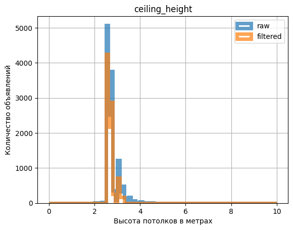

```python
# построим гистограммы на основе исходных данных
ax_6 = data.plot(
    kind='hist',
    y='ceiling_height',
    histtype='step',
    range=(0, 10),
    bins=100,
    linewidth=5,
    alpha=0.7,
    label='raw',
)
# накладываем на гистограмму после предобработки данных
good_data.plot(
    kind='hist',
    y='ceiling_height',
    histtype='step',
    range=(0, 10),
    bins=100,
    linewidth=5,
    alpha=0.7,
    label='filtered',
    ax=ax_6,
    grid=True,
    legend=True,
)

# дадим название графику и осям
ax_6.set_title('ceiling_height')
ax_6.set_xlabel('Высота потолков в метрах')
ax_6.set_ylabel('Количество объявлений')
```

**Вывод:**

1. Основная масса данных сконцентрирована в диапазоне 2.5–2.8 метров, что соответствует стандартным высотам жилых помещений.
2. Исправили очевидные ошибки, например, значения 27 и 32 метров заменили на 2.7 и 3.2.
3. Для дальнейшего анализа оставили реалистичные значения в диапазоне 2.5–3.22 метров.

#### Изучение типа этажа квартиры

Столбец `floor_type` содержит категориальные переменные, представляющие различные типы этажей. Чтобы наглядно отразить их распределение, построим столбчатую диаграмму:

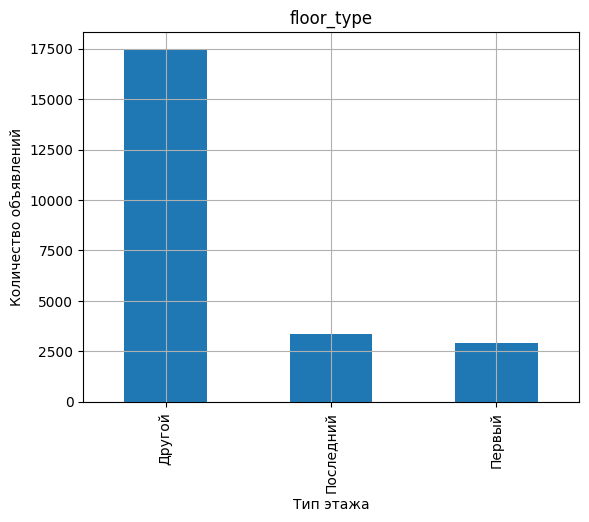

```python
# подсчитаем количество объявлений для каждого типа этажа
floor_type_counts = data['floor_type'].value_counts()

# построим столбчатую диаграмму методом plot
floor_type_counts.plot(kind='bar')

# обозначим заголовок диаграммы
# назовём оси'x' и 'y'
# добавим сетку
plt.title('floor_type')
plt.xlabel('Тип этажа')
plt.ylabel('Количество объявлений')
plt.grid(True)

# выведем диаграмму на экран
plt.show()
```

Проверим качество данных. Ознакомимся со списком уникальных значений столбца:

```python
# выведем список уникальных значений
data['floor_type'].unique()
```

```
array(['Другой', 'Первый', 'Последний'], dtype=object)
```

**Вывод:**

- В столбце отсутствуют выбросы и аномалии. Значения можно использовать для анализа в дальнейшем.

#### Изучение общего количества этажей

Рассмотрим гистограмму по столбцу `floors_total` с общим количеством этажей более детально:

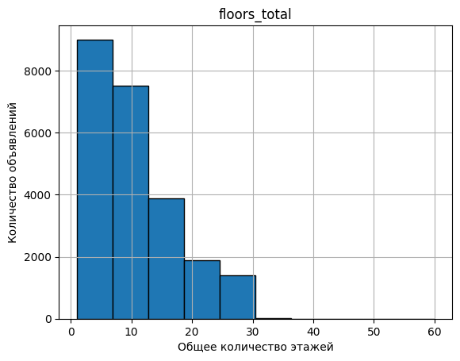

```python
# построим гистограмму с 10 корзинами по умолчанию
plt.hist(data['floors_total'], edgecolor='black')

# обозначим имя столбца
# назовём оси 'x' и 'y'
# добавим сетку
plt.title('floors_total')
plt.xlabel('Общее количество этажей')
plt.ylabel('Количество объявлений')
plt.grid(True)
```

- Больше всего объявлений с домами примерно `до 6 этажей`. Высотные дома `до 30 этажей` встречаются достаточно редко и после этой отметки количество объявлений резко сокращается. На гистограмме виден хвост примерно `до 36 этажей`. Возможно, в столбце присутствуют редкие и выбивающиеся значения.

Ознакомимся с числовым описанием данных:

```python
# выведем на экран числовое описание
data['floors_total'].describe()
```

```
count      23699.0
mean     10.681759
std       6.599383
min            1.0
25%            5.0
50%            9.0
75%           16.0
max           60.0
Name: floors_total, dtype: Float64
```

- Самое большое количество объявлений сосредоточено в диапазоне `от 5 до 16 этажей`.
- Среднее выше медианы на `1.6`, а стандартное отклонение составляет `6.5`. В данных действительно могут быть аномалии.
- Возможно, максимальное число `60` — является редким значением и смещает среднее вверх.

Построим диаграмму размаха и проверим данные на наличие выбросов:

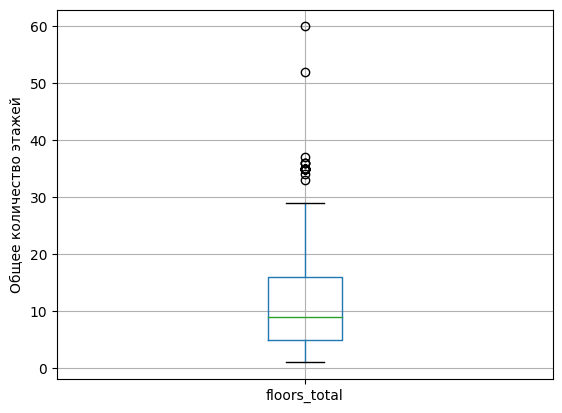

```python
# построим диаграмму размаха по столбцу с помощью метода boxplot()
data.boxplot(column='floors_total')

# назовём ось 'y'
plt.ylabel('Общее количество этажей')

# выведем диаграмму на экран
plt.show()
```

Посмотрим информацию о квартирах с высоким количеством этажей:

```python
# выведем результат на экран
filtered_data('floors_total', 50, 61)
```

|  | total_images | last_price | total_area | first_day_exposition | rooms | ceiling_height | floors_total | living_area | floor | is_apartment | ... | parks_nearest | ponds_around_3000m | ponds_nearest | days_exposition | price_per_square_meter | weekday_publication | month_publication | year_publication | floor_type | center_distance_km |
| --- | --- | --- | --- | --- | --- | --- | --- | --- | --- | --- | --- | --- | --- | --- | --- | --- | --- | --- | --- | --- | --- |
| 2253 | 12 | 3800000 | 45.5 | 2018-06-28 | 2 | 2.88 | 60 | 27.4 | 4 | False | ... | 342.0 | 3 | 614.0 | 166 | 83516.48 | 3 | 6 | 2018 | Другой | 49.0 |
| 16731 | 9 | 3978000 | 40.0 | 2018-09-24 | 1 | 2.65 | 52 | 10.5 | 18 | False | ... | 793.0 | 0 | NaN | 45 | 99450.00 | 0 | 9 | 2018 | Другой | 13.0 |

2 rows × 28 columns

Найдено две квартиры в домах с общим количеством этажей — `52` и `60`. Сомнения вызывает местоположение квартиры в доме с 60 этажами — 49 км. от центра города. Такое сочетание выглядит нестандартно, обычно высотные здания строят в черте города.

Удалим эти значения для более корректного результата исследования. Рассчитаем верхнюю границу выбросов с максимальной точностью:

```python
# вызовем функцию и выведем результат на экран
print(emission_limit('floors_total'))
```

```
Верхняя граница выбросов: 32.50
```

Отфильтруем данные в столбце:

```python
# отфильтруем данные с помощью guery() и сохраним результат в good_data
good_data = good_data.query('floors_total <= 32.00')

# проверим результат, выведем первые 10 строк столбца датафрейма, отсортированных по убыванию
good_data['floors_total'].sort_values(ascending=False).head(10)
```

```
3797     29
14719    28
6397     28
16984    28
14018    28
20876    28
12950    28
7711     28
14186    28
18183    28
Name: floors_total, dtype: Int64
```

Посмотрим на результат очистки данных:

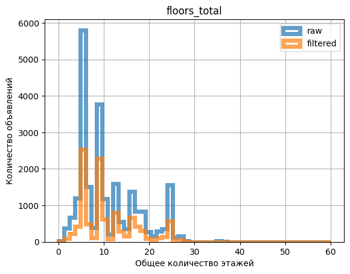

```python
# построим гистограммы на основе исходных данных
ax_7 = data.plot(
    kind='hist',
    y='floors_total',
    histtype='step',
    range=(0, 60),
    bins=50,
    linewidth=5,
    alpha=0.7,
    label='raw',
)
# накладываем на гистограмму после предобработки данных
good_data.plot(
    kind='hist',
    y='floors_total',
    histtype='step',
    range=(0, 60),
    bins=50,
    linewidth=5,
    alpha=0.7,
    label='filtered',
    ax=ax_7,
    grid=True,
    legend=True,
)


# дадим название графику и осям
ax_7.set_title('floors_total')
ax_7.set_xlabel('Общее количество этажей')
ax_7.set_ylabel('Количество объявлений')
```

**Вывод:**

1. Большинство объявлений относится к домам высотой до 16 этажей, а здания выше 30 этажей встречаются крайне редко.
2. Среднее значение выше медианы, что указывает на наличие выбросов. Диаграмма размаха и межквартильный размах подтвердили, что выбросами можно считать здания выше 32 этажей, включая аномальные значения 52 и 60 этажей.
3. После удаления выбросов распределение стало более однородным.

#### Изучение расстояния до центра города

Рассмотрим гистограмму по столбцу `city_centers_nearest` с расстоянием до центра города в метрах более детально:

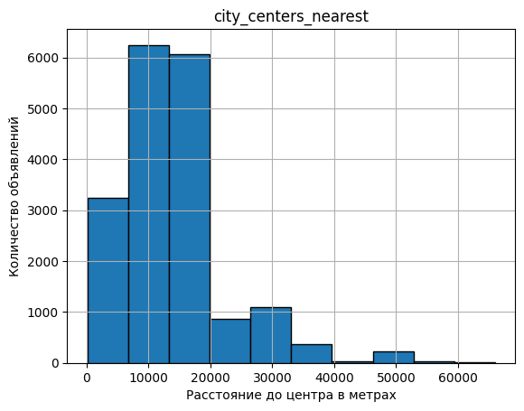

```python
# построим гистограмму с 10 корзинами по умолчанию
plt.hist(data['city_centers_nearest'], edgecolor='black')

# обозначим имя столбца
# назовём оси 'x' и 'y'
# добавим сетку
plt.title('city_сenters_nearest')
plt.xlabel('Расстояние до центра в метрах')
plt.ylabel('Количество объявлений')
plt.grid(True)
```

- Большинство объявлений относятся к квартирам в радиусе `до 20 км` от центра. Пик приходится примерно на `5–15 км`.
- Небольшое количество квартир находится значительно дальше, вплоть `до 60-70 км`.

Ознакомимся с числовым описанием данных:

```python
# выведем числовое описание с помощью метода describe()
data['city_centers_nearest'].describe()
```

```
count    18180.000000
mean     14191.277833
std       8608.386210
min        181.000000
25%       9238.000000
50%      13098.500000
75%      16293.000000
max      65968.000000
Name: city_centers_nearest, dtype: float64
```

- Самое большое количество объявлений сосредоточено в радиусе `от 9,24 до 16,29 км` до центра города.
- Среднее выше медианы, а стандартное отклонение составляет `8608.3`.
- Максимальное число `65968 метров`, то есть `65,97 км` — достаточно далёкое расстояния до центра города. Вероятно, такие квартиры находятся на окраине или в пригороде.

**Вывод:**

- Стандартное отклонение в данных указывает на возможное наличие выбросов в столбце. Однако с логической точки зрения далёкое расстояние до центра города объясняется тем, что в датафрейме представлены разные населённые пункты: не только города, но и посёлки или деревни. Фильтрация по верхней границе выбросов могла бы привести к потере большого количества ценных данных. Поэтому оставим значения в столбце без изменений.

#### Изучение расстояния до ближайшего парка

Рассмотрим гистограмму по столбцу `parks_nearest` с расстоянием до ближайшего парка более детально:

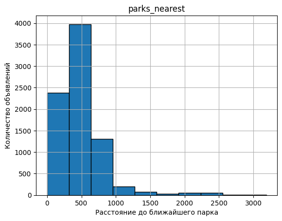

```python
# построим гистограмму с 10 корзинами по умолчанию
plt.hist(data['parks_nearest'], edgecolor='black')

# обозначим имя столбца
# назовём оси 'x' и 'y'
# добавим сетку
plt.title('parks_nearest')
plt.xlabel('Расстояние до ближайшего парка')
plt.ylabel('Количество объявлений')
plt.grid(True)

# выведем гистограмму
plt.show()
```

- Большинство объявлений сосредоточено на расстоянии до 500 метров от парков. Это может свидетельствовать о высокой востребованности жилья рядом с озеленённой территорией.
- Заметен длинный хвост, продолжающийся примерно до значения 3250 метров. Значит, в этом радиусе есть небольшое количество квартир.

Ознакомимся с числовым описанием данных:

```python
# выведем числовое описание с помощью метода describe()
data['parks_nearest'].describe()
```

```
count    8079.000000
mean      490.804555
std       342.317995
min         1.000000
25%       288.000000
50%       455.000000
75%       612.000000
max      3190.000000
Name: parks_nearest, dtype: float64
```

- Самое большое количество объявлений сосредоточено в радиусе `от 0,288 до 0,612 км` до ближайшего парка.
- Среднее выше медианы, а стандартное отклонение составляет `342.3`.
- Максимальное число `3,19 км` — выглядит реалистично. Это достаточно комфортное расстояния до парка.

**Вывод:**

- Хотя стандартное отклонение достаточно велико, аномалий в данных не наблюдается. Значения выглядят правдоподобно, и их фильтрация могла бы привести к потере ценной информации для дальнейшего анализа. Поэтому оставим данные в исходном виде.

### Анализ скорости продажи квартир

Изучим, как быстро продавались квартиры:

- Построим гистограмму;
- Рассчитаем среднее и медиану;
- Опишем, сколько обычно занимает продажа и укажем, какие продажи можно считать быстрыми, а какие — необычно долгими.

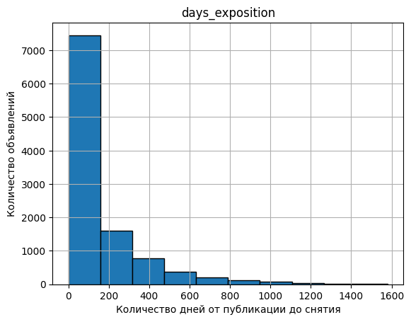

```python
# построим гистограмму с 10 корзинами по умолчанию
plt.hist(good_data['days_exposition'], edgecolor='black')

# обозначим заголовок - имя столбца
# назовём оси'y' и 'x'
# добавим сетку
plt.title('days_exposition')
plt.ylabel('Количество объявлений')
plt.xlabel('Количество дней от публикации до снятия')
plt.grid(True)
```

Ознакомимся с числовыми характеристиками столбца `days_exposition`:

```python
# выведем числовое описание данных
good_data['days_exposition'].describe()
```

```
count       10650.0
mean     166.186291
std      202.566446
min             1.0
25%            47.0
50%            95.0
75%           193.0
max          1580.0
Name: days_exposition, dtype: Float64
```

- Обычно продажа квартиры занимает около 166 дней.
- Продажу квартиры за 1 день можно считать необычно быстрой, а за 1580 дней — необычно долгой.

**Вывод:**

### Анализ факторов, влияющих на полную стоимость

Определим факторы, которые больше всего влияют на полную стоимость объекта. Построим графики и изучим, зависит ли цена от:

- Общей площади;
- Жилой площади;
- Площади кухни;
- Количества комнат;
- Тип этажа, на котором расположена квартира;
- Даты размещения (день недели, месяц, год).

Построим матрицу рассеяния для пар параметров: полная цена квартиры и общая площадь, полная цена и жилая площадь, полная цена площадь кухни.

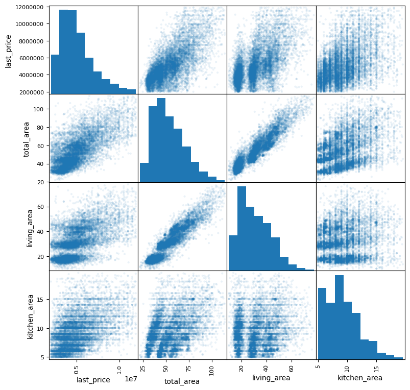

```python
# построим матрицу рассеяния
# зададим ширину и высоту матрицы
# сделаем точки полупрозрачными
# выведем диаграммы на экран
pd.plotting.scatter_matrix(
    good_data[
        [
        'last_price',
        'total_area',
        'living_area',
        'kitchen_area'
        ]
    ],
    figsize=(9, 9),
    alpha=0.09
)
plt.show()
```

- Наблюдается средняя положительная связь между полной ценой и общей площадью квартиры. В целом, увеличение площади сопровождается ростом цены, однако встречаются исключения. Чаще всего квартиры с площадью от 30 до 70 м² имеют наиболее плотное распределение цен.
- Связь между полной ценой и жилой площадью слабее. Видно две зоны с наиболее повышенной плотностью: в диапазонах жилой площади от 10 до 20 м² и от 27 до 33 м².
- Площадь кухни оказывает на цену наименьшее влияние. Заметна плотная зона для кухонь от 5 до 10 м². Далее значения распределены хаотично.

Чтобы наиболее точно оценить, насколько тесна взаимосвязь, дополним матрицу коэффициентом корреляции Пирсона:

```python
# рассчитаем коэффициент корреляции Пирсона
good_data[
        ['last_price',
        'total_area',
        'living_area',
        'kitchen_area']
    ].corr()
```

|  | last_price | total_area | living_area | kitchen_area |
| --- | --- | --- | --- | --- |
| last_price | 1.000000 | 0.697088 | 0.582057 | 0.467181 |
| total_area | 0.697088 | 1.000000 | 0.922493 | 0.413095 |
| living_area | 0.582057 | 0.922493 | 1.000000 | 0.140107 |
| kitchen_area | 0.467181 | 0.413095 | 0.140107 | 1.000000 |

- Расчеты подтверждают, что сильнее всего связаны общая площадь и полная цена квартиры.
- Наименее выражена связь между полной ценой и площадью кухни.

Построим график, поделённый на шестиугольные области, для пары параметров `полная цена` и `количество комнат`:

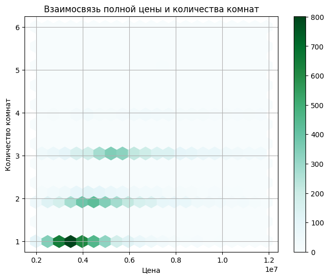

```python
# построим график
# поставим костыль sharex=False
price_and_rooms = good_data.plot(
    x='last_price',
    y='rooms',
    kind='hexbin',
    gridsize=20,
    figsize=(8,6),
    sharex=False,
    grid=True
)

price_and_rooms.set_title('Взаимосвязь полной цены и количества комнат')
price_and_rooms.set_xlabel('Цена')
price_and_rooms.set_ylabel('Количество комнат')
```

- Видна средняя положительная взаимосвязь между ценой и количеством комнат. Особенно плотная зона — квартиры с 1 комнатой.

Дополним график коэффициентом корреляции Пирсона:

```python
# рассчитаем коэффициент корреляции Пирсона
good_data[
        ['last_price',
        'rooms'
        ]
    ].corr()
```

|  | last_price | rooms |
| --- | --- | --- |
| last_price | 1.000000 | 0.448016 |
| rooms | 0.448016 | 1.000000 |

- Расчёты подтверждают среднюю связь между параметрами.

Построим столбчатую диаграмму для пары параметров: `общая цена` и `тип этажа квартиры`

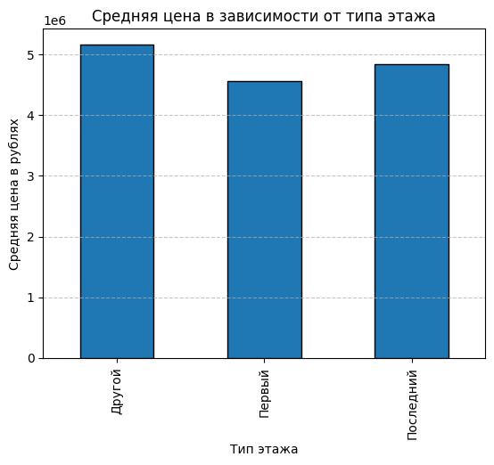

```python
# найдём среднюю цену квартир для каждого типа этажа
price_and_floor_type = good_data.groupby('floor_type')['last_price'].mean()

# построим столбчатую диаграмму методом plot
price_and_floor_type.plot(kind='bar', edgecolor='black')

# обозначим заголовок диаграммы
# назовём оси'x' и 'y'
# добавим сетку
plt.title('Средняя цена в зависимости от типа этажа')
plt.xlabel('Тип этажа')
plt.ylabel('Средняя цена в рублях')
plt.grid(True, axis='y', linestyle='--', alpha=0.7)

# выведем диаграмму на экран
plt.show()
```

- Видна слабая взаимосвязь между ценой объекта и типом этажа квартиры. Наиболее высокая средняя цена на квартиры на разных этажах, кроме первого и последнего. Самая низкая средняя цена - на квартиры на первом этаже.

Построим матрицу рассеяния для пар параметров: полная цена и день недели, полная цена и месяц, полная цена и год публикации объявления.

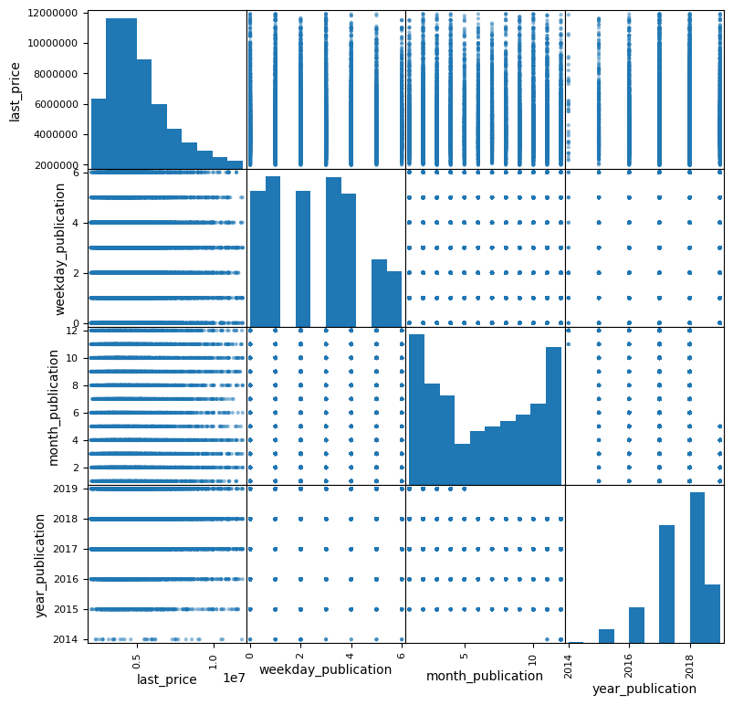

```python
# построим матрица рассеяния
# зададим ширину и высоту матрицы
# сделаем точки полупрозрачными
# выведем диаграммы на экран
pd.plotting.scatter_matrix(
    good_data[
        [
        'last_price',
        'weekday_publication',
        'month_publication',
        'year_publication'
        ]
    ],
    figsize=(9, 9))
plt.show()
```

- Фактор публикации объявления (день, месяц, год) практически не влияет на стоимость объекта недвижимости.

Сделаем расчёты:

```python
# рассчитаем коэффициент корреляции Пирсона
good_data[
        ['last_price',
        'weekday_publication',
        'month_publication',
        'year_publication']
    ].corr()
```

|  | last_price | weekday_publication | month_publication | year_publication |
| --- | --- | --- | --- | --- |
| last_price | 1.000000 | -0.013266 | -0.005955 | 0.025012 |
| weekday_publication | -0.013266 | 1.000000 | -0.005794 | 0.003331 |
| month_publication | -0.005955 | -0.005794 | 1.000000 | -0.287220 |
| year_publication | 0.025012 | 0.003331 | -0.287220 | 1.000000 |

- Коэффициент корреляции показывает незначительную отрицательную связь полной цены с неделей и месяцем публикации. Можно утверждать, что взаимосвязь практически отсутствует.

### Анализ стоимости м² в населённых пунктах

Посчитаем среднюю цену одного квадратного метра в 10 населённых пунктах с наибольшим числом объявлений:

- Построим сводную таблицу с количеством объявлений и средней ценой квадратного метра для этих населенных пунктов.
- Выделим населённые пункты с самой высокой и низкой стоимостью квадратного метра.

```python
# построим сводную таблицу
# подсчитаем количество строк и среднее значение в столбце
# выведем 10 строк, отсортированных по убыванию
good_data_pivot_table = (

    good_data.pivot_table(
    index='locality_name',
    values='price_per_square_meter',
    aggfunc=['count','mean'])
    .sort_values(by=('count', 'price_per_square_meter'), ascending=False)
    .head(10)
)

# выведем результат на экран
good_data_pivot_table
```

| locality_name | count price_per_square_meter | mean price_per_square_meter |
| --- | --- | --- |
| Санкт-Петербург | 7464 | 105233.349854 |
| Всеволожск | 232 | 67991.587198 |
| посёлок Шушары | 197 | 79444.757360 |
| Мурино | 192 | 87418.192396 |
| Колпино | 184 | 75531.337500 |
| Пушкин | 182 | 100129.380934 |
| Кудрово | 155 | 96664.619226 |
| посёлок Парголово | 129 | 91259.437597 |
| Петергоф | 129 | 83391.381628 |
| Гатчина | 118 | 70785.378305 |

```python
# выведем максимальное и минимальное значение столбца, округлив до целого
good_data_pivot_table['mean'].max().round(0), good_data_pivot_table['mean'].min().round(0)
```

```
(price_per_square_meter    105233.0
 dtype: float64,
 price_per_square_meter    67992.0
 dtype: float64)
```

**Вывод:**

1. В Санкт-Петербурге самое большое количество объявлений и наиболее высокая средняя цена за 1 м², что типично для мегаполиса.
2. На втором месте по числу объявлений — Всеволожск, однако здесь самая низкая средняя цена за 1 м² — 67 992 рубля. Это можно объяснить меньшей популярностью и размерами города.

### Анализ взаимосвязи между стоимостью и расстоянием до центра

Вычислим среднюю стоимость квартир в Санкт-Петербурге на разном удалении от центра:

- Построим график изменения средней цены для каждого километра от центра Петербурга.
- Опишим, как стоимость объектов зависит от расстояния до центра города.

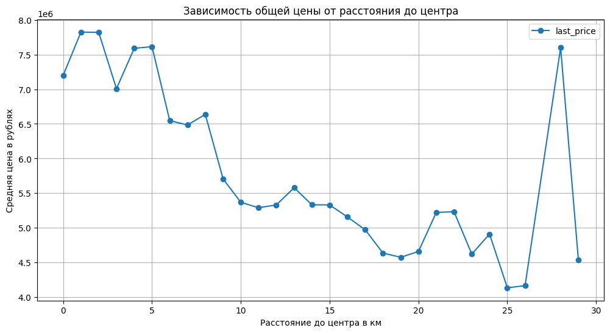

```python
# сделаем срез по столбцу с помощью query()
# рассчитаем среднюю цену за каждый километр
# построим график
price_and_distance = (good_data
    .query('locality_name == "Санкт-Петербург"')
    .pivot_table(index='center_distance_km', values='last_price')
    .plot(grid=True,figsize=(12,6),style='o-')
)

# дадим название графику и осям
price_and_distance.set_title('Зависимость общей цены от расстояния до центра')
price_and_distance.set_xlabel('Расстояние до центра в км')
price_and_distance.set_ylabel('Средняя цена в рублях')
```

- Чем ближе расположение объекта к центру Санкт-Петербурга - тем выше средняя цена на квартиру.
- Средняя цена резко возрастает на расстоянии 28 км - до 7 600 000 рублей. На отметке в 29 км цена снова опускается до 4 535 000 рублей.

```python
# отфильтруем нужные строки с помощью query()
data.query('locality_name == "Санкт-Петербург" and center_distance_km == 28.0')
```

|  | total_images | last_price | total_area | first_day_exposition | rooms | ceiling_height | floors_total | living_area | floor | is_apartment | ... | parks_nearest | ponds_around_3000m | ponds_nearest | days_exposition | price_per_square_meter | weekday_publication | month_publication | year_publication | floor_type | center_distance_km |
| --- | --- | --- | --- | --- | --- | --- | --- | --- | --- | --- | --- | --- | --- | --- | --- | --- | --- | --- | --- | --- | --- |
| 814 | 0 | 7600000 | 111.0 | 2017-07-26 | 3 | 3.0 | 16 | 63.0 | 12 | False | ... | 185.0 | 2 | 72.0 | 66 | 68468.47 | 2 | 7 | 2017 | Другой | 28.0 |
| 1111 | 0 | 4072000 | 38.0 | 2015-10-14 | 1 | NaN | 5 | 16.0 | 4 | False | ... | NaN | 0 | NaN | 285 | 107157.89 | 2 | 10 | 2015 | Другой | 28.0 |
| 9572 | 0 | 3413000 | 43.0 | 2015-11-10 | 1 | NaN | 5 | 18.0 | 1 | False | ... | NaN | 0 | NaN | 258 | 79372.09 | 1 | 11 | 2015 | Первый | 28.0 |
| 17798 | 0 | 4990000 | 71.0 | 2015-10-14 | 3 | NaN | 5 | 42.0 | 1 | False | ... | NaN | 0 | NaN | 285 | 70281.69 | 2 | 10 | 2015 | Первый | 28.0 |
| 18941 | 0 | 3666000 | 39.0 | 2015-11-09 | 1 | NaN | 5 | 16.0 | 2 | False | ... | NaN | 0 | NaN | 259 | 94000.00 | 0 | 11 | 2015 | Другой | 28.0 |
| 22916 | 0 | 5144000 | 64.0 | 2015-10-14 | 2 | NaN | 5 | 33.0 | 5 | False | ... | NaN | 0 | NaN | 285 | 80375.00 | 2 | 10 | 2015 | Последний | 28.0 |
| 23145 | 17 | 6300000 | 92.0 | 2017-07-20 | 3 | NaN | 16 | 46.0 | 7 | False | ... | 36.0 | 2 | 46.0 | 14 | 68478.26 | 3 | 7 | 2017 | Другой | 28.0 |

7 rows × 28 columns

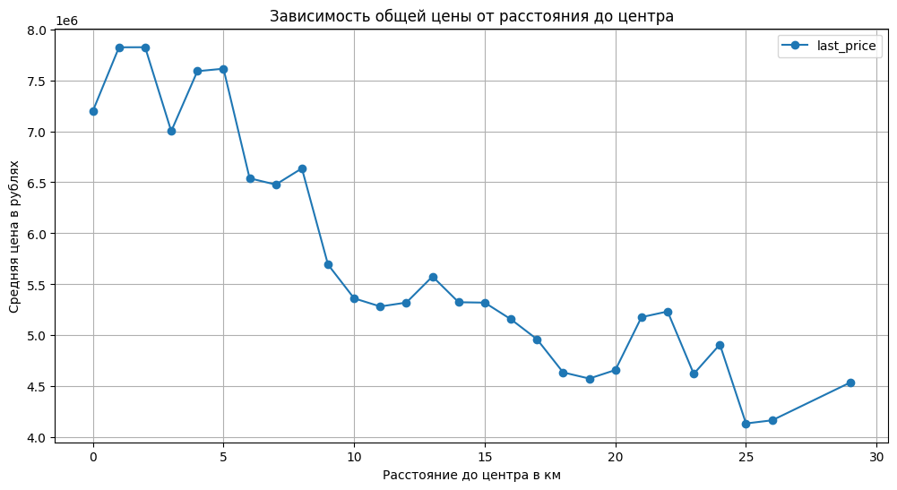

```python
# сделаем срез по столбцу с помощью query()
# рассчитаем медианную цену за каждый километр
# построим график
price_and_distance_2 = (good_data
    .query('locality_name == "Санкт-Петербург" and last_price != 7600000.0')
    .pivot_table(index='center_distance_km', values='last_price')
    .plot(grid=True,figsize=(12,6),style='o-')
)

# дадим название графику и осям
price_and_distance_2.set_title('Зависимость общей цены от расстояния до центра')
price_and_distance_2.set_xlabel('Расстояние до центра в км')
price_and_distance_2.set_ylabel('Средняя цена в рублях')
```

## Общий вывод

В ходе исследовательского анализа данных мы изучили параметры объектов и установили:

1. Наличие аномальных значений и выбросов в столбцах: `общая площадь`, `жилая площадь`, `площадь кухни`, `цена объекта`, `количество комнат`, `высота потолков`, `общее количество этажей в доме`.
2. Отсутствие аномалий в данных о `типе этажа квартиры («первый», «последний», «другой»)`, `расстоянии до центра города в метрах`, `расстоянии до ближайшего парка`.

Обработали выбросы с помощью диаграммы размаха и межквартильного размаха.

Установили параметры, влияющие на цену объектов: